# Прогнозирование оттока клиентов телеком-оператора ТелеДом

Оператор связи «ТелеДом» хочет бороться с оттоком клиентов. Для этого его сотрудники начнут предлагать промокоды и специальные условия всем, кто планирует отказаться от услуг связи. Чтобы заранее находить таких пользователей, «ТелеДому» нужна модель, которая будет предсказывать, разорвёт ли абонент договор. Команда оператора собрала персональные данные о некоторых клиентах, информацию об их тарифах и услугах. Задача — обучить на этих данных модель для прогноза оттока клиентов.

**Цели и задачи проекта**

Основная цель проекта – разработать модель машинного обучения, которая сможет предсказывать вероятность оттока клиентов телеком-оператора TeleDom на основе анализа их поведения и использования услуг.

Задачи проекта включают:

- Анализ предоставленных данных о клиентах и их использовании услуг.
- Предобработка данных для подготовки к обучению модели.
- Выбор и обучение модели машинного обучения для прогнозирования оттока.
- Оценка эффективности модели с использованием соответствующих метрик.

Критерии успеха:  
Проект будет считаться успешным, если достигнуты следующие показатели:

- AUC-ROC выше 0.85.

# **Шаг 1. Загрузка данных**

```python
!pip install pyspark
!pip install phik
!pip install catboost
!pip install --upgrade scikit-learn

import pandas as pd
import numpy as np
import matplotlib.pyplot as plt
import seaborn as sns
import phik
import sklearn
import pickle
from sklearn.preprocessing import OneHotEncoder
from pyspark.sql import SparkSession
from phik import resources, report
from sklearn.model_selection import train_test_split, RandomizedSearchCV, cross_val_score
from sklearn.compose import ColumnTransformer
from sklearn.preprocessing import StandardScaler, OneHotEncoder
from sklearn.pipeline import Pipeline
from sklearn.impute import SimpleImputer
from catboost import CatBoostClassifier, Pool
from sklearn.metrics import roc_auc_score
from sklearn.metrics import accuracy_score
from sklearn.linear_model import LogisticRegression
from scipy.stats import uniform
from sklearn.metrics import roc_curve, auc
from sklearn.metrics import confusion_matrix
```

```python
RANDOM_STATE=190224
```

```python
from google.colab import drive
drive.mount('/content/drive/')
```

```python
#load datasets
contract = pd.read_csv('/content/drive/MyDrive/datasets/contract_new.csv')

display(contract.head())
```

|  | customerID | BeginDate | EndDate | Type | PaperlessBilling | PaymentMethod | MonthlyCharges | TotalCharges |
| --- | --- | --- | --- | --- | --- | --- | --- | --- |
| 0 | 7590-VHVEG | 2020-01-01 | No | Month-to-month | Yes | Electronic check | 29.85 | 31.04 |
| 1 | 5575-GNVDE | 2017-04-01 | No | One year | No | Mailed check | 56.95 | 2071.84 |
| 2 | 3668-QPYBK | 2019-10-01 | No | Month-to-month | Yes | Mailed check | 53.85 | 226.17 |
| 3 | 7795-CFOCW | 2016-05-01 | No | One year | No | Bank transfer (automatic) | 42.30 | 1960.6 |
| 4 | 9237-HQITU | 2019-09-01 | No | Month-to-month | Yes | Electronic check | 70.70 | 353.5 |

```python
#size of dataset contract
contract.shape
```

```
(7043, 8)
```

```python
contract.info()
```

```
<class 'pandas.core.frame.DataFrame'>
RangeIndex: 7043 entries, 0 to 7042
Data columns (total 8 columns):
 #   Column            Non-Null Count  Dtype
---  ------            --------------  -----
 0   customerID        7043 non-null   object
 1   BeginDate         7043 non-null   object
 2   EndDate           7043 non-null   object
 3   Type              7043 non-null   object
 4   PaperlessBilling  7043 non-null   object
 5   PaymentMethod     7043 non-null   object
 6   MonthlyCharges    7043 non-null   float64
 7   TotalCharges      7043 non-null   object
dtypes: float64(1), object(7)
memory usage: 440.3+ KB
```

```python
print(contract.isnull().sum())
```

```
customerID          0
BeginDate           0
EndDate             0
Type                0
PaperlessBilling    0
PaymentMethod       0
MonthlyCharges      0
TotalCharges        0
dtype: int64
```

```python
duplicate_count = contract.duplicated(subset='customerID', keep=False).sum()
print(duplicate_count)
```

```
0
```

Первичный анализ данных был проведен в наборе данных «контракт». 7043 строки, 8 столбцов. Некоторые типы данных следует изменить, чтобы они лучше соответствовали содержащейся в них информации. Данные следует проверить на наличие явных и скрытых дубликатов.

```python
#load dataset
internet = pd.read_csv('/content/drive/MyDrive/datasets/internet_new.csv')
display(internet.head())
```

|  | customerID | InternetService | OnlineSecurity | OnlineBackup | DeviceProtection | TechSupport | StreamingTV | StreamingMovies |
| --- | --- | --- | --- | --- | --- | --- | --- | --- |
| 0 | 7590-VHVEG | DSL | No | Yes | No | No | No | No |
| 1 | 5575-GNVDE | DSL | Yes | No | Yes | No | No | No |
| 2 | 3668-QPYBK | DSL | Yes | Yes | No | No | No | No |
| 3 | 7795-CFOCW | DSL | Yes | No | Yes | Yes | No | No |
| 4 | 9237-HQITU | Fiber optic | No | No | No | No | No | No |

```python
#size of dataset internet
internet.shape
```

```
(5517, 8)
```

```python
internet.info()
```

```
<class 'pandas.core.frame.DataFrame'>
RangeIndex: 5517 entries, 0 to 5516
Data columns (total 8 columns):
 #   Column            Non-Null Count  Dtype
---  ------            --------------  -----
 0   customerID        5517 non-null   object
 1   InternetService   5517 non-null   object
 2   OnlineSecurity    5517 non-null   object
 3   OnlineBackup      5517 non-null   object
 4   DeviceProtection  5517 non-null   object
 5   TechSupport       5517 non-null   object
 6   StreamingTV       5517 non-null   object
 7   StreamingMovies   5517 non-null   object
dtypes: object(8)
memory usage: 344.9+ KB
```

```python
print(internet.isnull().sum())
```

```
customerID          0
InternetService     0
OnlineSecurity      0
OnlineBackup        0
DeviceProtection    0
TechSupport         0
StreamingTV         0
StreamingMovies     0
dtype: int64
```

```python
duplicate_count = internet.duplicated(subset='customerID', keep=False).sum()
print(duplicate_count)
```

```
0
```

Первичный анализ данных был проведен в наборе данных «Интернет». 5517 строк, 8 столбцов. Некоторые типы данных следует изменить, чтобы они лучше соответствовали содержащейся в них информации.

```python
personal = pd.read_csv('/content/drive/MyDrive/datasets/personal_new.csv')
display(personal.head())
```

|  | customerID | gender | SeniorCitizen | Partner | Dependents |
| --- | --- | --- | --- | --- | --- |
| 0 | 7590-VHVEG | Female | 0 | Yes | No |
| 1 | 5575-GNVDE | Male | 0 | No | No |
| 2 | 3668-QPYBK | Male | 0 | No | No |
| 3 | 7795-CFOCW | Male | 0 | No | No |
| 4 | 9237-HQITU | Female | 0 | No | No |

```python
#size of dataset personal
personal.shape
```

```
(7043, 5)
```

```python
personal.info()
```

```
<class 'pandas.core.frame.DataFrame'>
RangeIndex: 7043 entries, 0 to 7042
Data columns (total 5 columns):
 #   Column         Non-Null Count  Dtype
---  ------         --------------  -----
 0   customerID     7043 non-null   object
 1   gender         7043 non-null   object
 2   SeniorCitizen  7043 non-null   int64
 3   Partner        7043 non-null   object
 4   Dependents     7043 non-null   object
dtypes: int64(1), object(4)
memory usage: 275.2+ KB
```

```python
print(personal.isnull().sum())
```

```
customerID       0
gender           0
SeniorCitizen    0
Partner          0
Dependents       0
dtype: int64
```

```python
duplicate_count = personal.duplicated(subset='customerID', keep=False).sum()
print(duplicate_count)
```

```
0
```

Первичный анализ данных был проведен в «personal» наборе данных. 7043 строки, 5 столбцов. Некоторые типы данных следует изменить, чтобы они лучше соответствовали содержащейся в них информации. Данные следует проверить на наличие явных и скрытых дубликатов.

```python
phone = pd.read_csv('/content/drive/MyDrive/datasets/phone_new.csv')
display(phone.head())
```

|  | customerID | MultipleLines |
| --- | --- | --- |
| 0 | 5575-GNVDE | No |
| 1 | 3668-QPYBK | No |
| 2 | 9237-HQITU | No |
| 3 | 9305-CDSKC | Yes |
| 4 | 1452-KIOVK | Yes |

```python
#size of dataset phone
phone.shape
```

```
(6361, 2)
```

```python
phone.info()
```

```
<class 'pandas.core.frame.DataFrame'>
RangeIndex: 6361 entries, 0 to 6360
Data columns (total 2 columns):
 #   Column         Non-Null Count  Dtype
---  ------         --------------  -----
 0   customerID     6361 non-null   object
 1   MultipleLines  6361 non-null   object
dtypes: object(2)
memory usage: 99.5+ KB
```

```python
print(phone.isnull().sum())
```

```
customerID       0
MultipleLines    0
dtype: int64
```

```python
duplicate_count = phone.duplicated(subset='customerID', keep=False).sum()
print(duplicate_count)
```

```
0
```

Первоначальный анализ данных был проведен в наборе данных «Phone». 6361 строка, 2 столбца.Пропущенные данные отсутствуют. Дубликаты по customerID отсуствуют

Данные из 4 наборов данных были успешно загружены. Данные необходимо предварительно обработать. Это будет сделано в следующем разделе.

# **Шаг 2. Исследовательский анализ данных и предобработка**

## Датасет Contract

В данном датасете необходимо выполнить следующие шаги для исследовательского анализа данных и предобработки:  
-Перевод названия колонок в нижний регистр, так как это является общепринятой практикой.  
-Поиск явных дубликатов  
-Поиск пропущенных данных  
-Удаление явных дубликатов, если они есть  
-Перевод формата столбцов с датами в формат datetime64  
-Перевод totalcharges в числовой формат  
-Если в этой колонке будут найдены пропуски - это будет означать, что существуют клиенты, которые еще не успели внести ни одну плату, и следовательно эти данные можно будет заменить 0  
-Необходимо завести целевую переменную - отток клиентов - если они разорвали контракт в колонке enddate будет стоять дата окончания контракта  
-Если дата окончания контракта не стоит, следовательно клиент продолжает пользоваться услугами, и можно заменить пропущенные данные на дату 2020-02-01 - контракты актуальны до этой даты. -Для числовых данных провести анализ на разброс данных и выбросы с помощью графика Boxplot  
-Провести анализ распределения целевой переменной Churn.

```python
#converting column names to lowercase
contract.columns = contract.columns.str.lower()
```

```python
#looking for obvious duplicates
duplicates = contract.duplicated()
print(duplicates.sum())
```

```
0
```

```python
#delete dublicates
contract = contract.drop_duplicates()
contract.info()
```

```
<class 'pandas.core.frame.DataFrame'>
Int64Index: 7043 entries, 0 to 7042
Data columns (total 8 columns):
 #   Column            Non-Null Count  Dtype
---  ------            --------------  -----
 0   customerid        7043 non-null   object
 1   begindate         7043 non-null   object
 2   enddate           7043 non-null   object
 3   type              7043 non-null   object
 4   paperlessbilling  7043 non-null   object
 5   paymentmethod     7043 non-null   object
 6   monthlycharges    7043 non-null   float64
 7   totalcharges      7043 non-null   object
dtypes: float64(1), object(7)
memory usage: 495.2+ KB
```

```python
# Convert 'begindate' and 'enddate' to datetime
contract['begindate'] = pd.to_datetime(contract['begindate'])
contract['enddate'] = pd.to_datetime(contract['enddate'], errors='coerce')

# Convert 'totalcharges' to numeric, errors='coerce' will replace non-numeric values with NaN
contract['totalcharges'] = pd.to_numeric(contract['totalcharges'], errors='coerce')

# Check the new data types
print(contract.info())
```

```
<class 'pandas.core.frame.DataFrame'>
Int64Index: 7043 entries, 0 to 7042
Data columns (total 8 columns):
 #   Column            Non-Null Count  Dtype
---  ------            --------------  -----
 0   customerid        7043 non-null   object
 1   begindate         7043 non-null   datetime64[ns]
 2   enddate           1101 non-null   datetime64[ns]
 3   type              7043 non-null   object
 4   paperlessbilling  7043 non-null   object
 5   paymentmethod     7043 non-null   object
 6   monthlycharges    7043 non-null   float64
 7   totalcharges      7032 non-null   float64
dtypes: datetime64[ns](2), float64(2), object(4)
memory usage: 495.2+ KB
None
```

```python
# Replacing all types of missing values with 0
contract['totalcharges'].fillna(0, inplace=True)
```

Найденные пропуски totalcharges предположительно означают,что существуют клиенты, которые еще не успели внести ни одну плату, и следовательно эти данные можно будет заменить 0

```python
# Creating a target column 'churn' indicating whether a customer has churned
# 1 if 'end_date' has a date (the contract was terminated), 0 otherwise
contract['churn'] = contract['enddate'].notna().astype(int)

# Checking the distribution of the target variable
print(contract['churn'].value_counts())
```

```
0    5942
1    1101
Name: churn, dtype: int64
```

```python
contract.info()
```

```
<class 'pandas.core.frame.DataFrame'>
Int64Index: 7043 entries, 0 to 7042
Data columns (total 9 columns):
 #   Column            Non-Null Count  Dtype
---  ------            --------------  -----
 0   customerid        7043 non-null   object
 1   begindate         7043 non-null   datetime64[ns]
 2   enddate           1101 non-null   datetime64[ns]
 3   type              7043 non-null   object
 4   paperlessbilling  7043 non-null   object
 5   paymentmethod     7043 non-null   object
 6   monthlycharges    7043 non-null   float64
 7   totalcharges      7043 non-null   float64
 8   churn             7043 non-null   int64
dtypes: datetime64[ns](2), float64(2), int64(1), object(4)
memory usage: 550.2+ KB
```

```python
#replace missing end_date because the information in contracts is actual  to 2020-02-01
replacement_date = pd.Timestamp('2020-02-01')
contract['enddate'] = contract['enddate'].fillna(replacement_date)
```

```python
contract.head(3)
```

|  | customerid | begindate | enddate | type | paperlessbilling | paymentmethod | monthlycharges | totalcharges | churn |
| --- | --- | --- | --- | --- | --- | --- | --- | --- | --- |
| 0 | 7590-VHVEG | 2020-01-01 | 2020-02-01 | Month-to-month | Yes | Electronic check | 29.85 | 31.04 | 0 |
| 1 | 5575-GNVDE | 2017-04-01 | 2020-02-01 | One year | No | Mailed check | 56.95 | 2071.84 | 0 |
| 2 | 3668-QPYBK | 2019-10-01 | 2020-02-01 | Month-to-month | Yes | Mailed check | 53.85 | 226.17 | 0 |

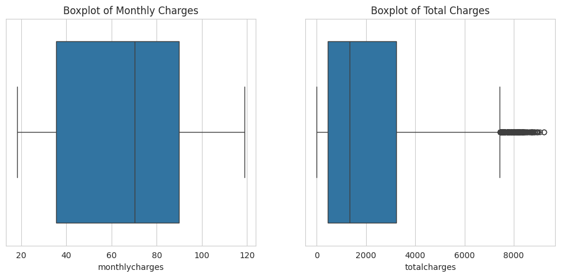

```python
# Set the aesthetic style of the plots
sns.set_style("whitegrid")

# Creating boxplots for 'monthlycharges' and 'totalcharges'
plt.figure(figsize=(12, 5))

plt.subplot(1, 2, 1)
sns.boxplot(x=contract['monthlycharges'])
plt.title('Boxplot of Monthly Charges')

plt.subplot(1, 2, 2)
sns.boxplot(x=contract['totalcharges'])
plt.title('Boxplot of Total Charges')

plt.show()
```

Был проведен анализ аномалий и выбросов, при этом особое внимание было уделено столбцу TotalCharges. В результате анализа стало ясно, что в данных наблюдаются значительные разбросы, что может указывать на наличие долгосрочных клиентов с высокими общими затратами.

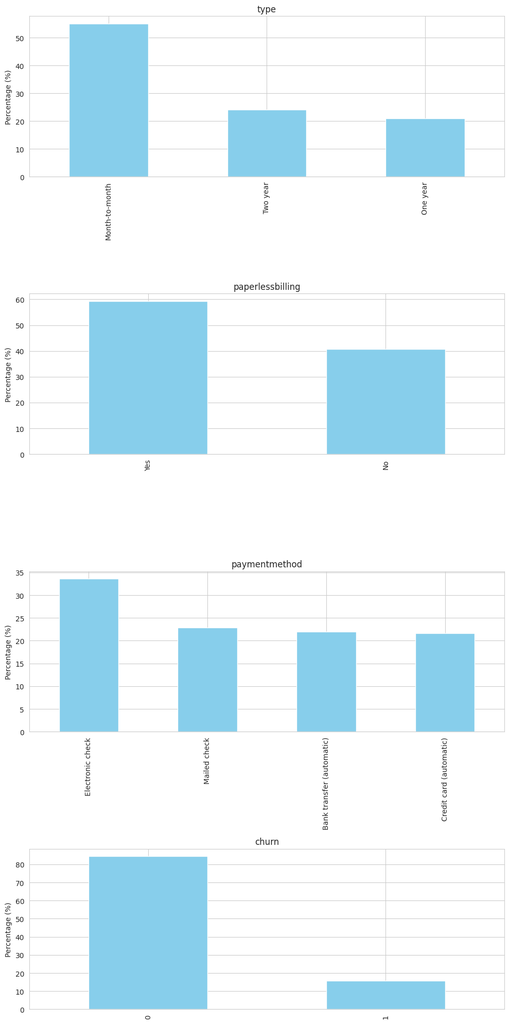

```python
columns = ['type', 'paperlessbilling', 'paymentmethod', 'churn']

fig, axes = plt.subplots(nrows=len(columns), ncols=1, figsize=(10, 20))

for i, col in enumerate(columns):

    value_counts = contract[col].value_counts(normalize=True) * 100
    value_counts.plot(kind='bar', ax=axes[i], title=col, color='skyblue')
    axes[i].set_ylabel('Percentage (%)')
    axes[i].set_xlabel('')

plt.tight_layout()
plt.show()
```

Среди типов оплаты контракта преобладает -ежемесячный

Электронный тип оплаты преобадает,остальные 3 типа оплаты занимают примерно одинаковые пропорции

Электронный расчётный лист запрашивает больше половины клиентов.

```python
contract['churn'].describe()
```

```
count    7043.000000
mean        0.156325
std         0.363189
min         0.000000
25%         0.000000
50%         0.000000
75%         0.000000
max         1.000000
Name: churn, dtype: float64
```

В рамках раздела «Исследовательский анализ и предварительная обработка данных» для набора данных «Contract» были выполнены следующие действия и сделаны соответствующие выводы:

Предварительная проверка данных. Набор данных был тщательно проверен на предмет типов данных, пропущенных значений и общего содержания. Было обнаружено, что данные содержат как числовые, так и категориальные характеристики, а также отсутствующие значения в столбце EndDate.

Обработка пропущенных значений. Отсутствующие значения в EndDate интерпретировались как индикаторы текущих контрактов (клиенты продолжают пользоваться услугами). Эти значения заменены на дату 01.02.2020 - данные в договорах актуальны до этой даты.

Анализ и обработка аномалий. Был проведен анализ аномалий и выбросов, при этом особое внимание было уделено столбцу TotalCharges. В результате анализа стало ясно, что в данных наблюдаются значительные разбросы, что может указывать на наличие долгосрочных клиентов с высокими общими затратами.

Среди типов оплаты контракта преобладает -ежемесячный.Электронный расчётный лист запрашивает больше половины клиентов. Электронный тип оплаты преобадает.

Анализ целевой переменной: был проведен анализ распределения целевой переменной (отток клиентов), который показал, что около 15,63% клиентов расторгли договор. Это обеспечивает основу для дальнейшего построения модели прогнозирования оттока клиентов.

## Датасет **Internet**

В данном датасете необходимо выполнить следующие шаги для исследовательского анализа данных и предобработки:  
-Перевод названия колонок в нижний регистр, так как это является общепринятой практикой.  
-Поиск пропущенных данных  
-Дубликаты в данном датасете не требуют удаления,так как данные в колонках не носят персонафицированный характер и могут быть одинакомыми для нескольких клиентов  
-Проанализировать распределение категориальных данных

```python
internet.head()
```

|  | customerID | InternetService | OnlineSecurity | OnlineBackup | DeviceProtection | TechSupport | StreamingTV | StreamingMovies |
| --- | --- | --- | --- | --- | --- | --- | --- | --- |
| 0 | 7590-VHVEG | DSL | No | Yes | No | No | No | No |
| 1 | 5575-GNVDE | DSL | Yes | No | Yes | No | No | No |
| 2 | 3668-QPYBK | DSL | Yes | Yes | No | No | No | No |
| 3 | 7795-CFOCW | DSL | Yes | No | Yes | Yes | No | No |
| 4 | 9237-HQITU | Fiber optic | No | No | No | No | No | No |

```python
#converting column names to lowercase
internet.columns = internet.columns.str.lower()
```

```python
internet.info()
```

```
<class 'pandas.core.frame.DataFrame'>
RangeIndex: 5517 entries, 0 to 5516
Data columns (total 8 columns):
 #   Column            Non-Null Count  Dtype
---  ------            --------------  -----
 0   customerid        5517 non-null   object
 1   internetservice   5517 non-null   object
 2   onlinesecurity    5517 non-null   object
 3   onlinebackup      5517 non-null   object
 4   deviceprotection  5517 non-null   object
 5   techsupport       5517 non-null   object
 6   streamingtv       5517 non-null   object
 7   streamingmovies   5517 non-null   object
dtypes: object(8)
memory usage: 344.9+ KB
```

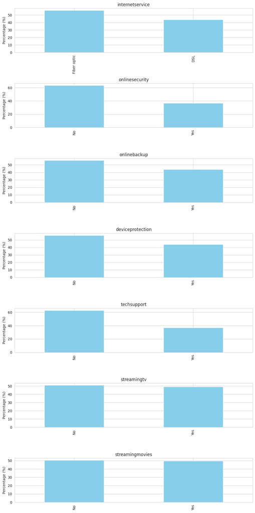

```python
columns = ['internetservice', 'onlinesecurity', 'onlinebackup', 'deviceprotection',
           'techsupport', 'streamingtv', 'streamingmovies']

fig, axes = plt.subplots(nrows=len(columns), ncols=1, figsize=(10, 20))

for i, col in enumerate(columns):

    value_counts = internet[col].value_counts(normalize=True) * 100
    value_counts.plot(kind='bar', ax=axes[i], title=col, color='skyblue')
    axes[i].set_ylabel('Percentage (%)')
    axes[i].set_xlabel('')

plt.tight_layout()
plt.show()
```

Использование оптоволокна: примерно 56,12% пользователей используют оптоволоконное подключение к Интернету. Это свидетельствует о высокой популярности оптоволокна среди рассматриваемой выборки пользователей.

Интернет-безопасность: около 36,60% пользователей подписываются на службу онлайн-безопасности. Это показывает, что услуга не так популярна, как могла бы быть, возможно, из-за дополнительной стоимости или недостаточной осведомленности пользователей о преимуществах.

Онлайн-резервное копирование. Службой онлайн-резервного копирования пользуются примерно 44,03% пользователей. Это говорит об умеренной популярности сервиса.

Защита устройства. Примерно 43,90% пользователей воспользовались услугой защиты устройств, что практически идентично популярности онлайн-резервного копирования.

Техподдержка: услугами технической поддержки пользуются около 37,05% пользователей, что делает ее сравнительно менее популярной среди предлагаемых услуг.

Интернет-телевидение (потоковое телевидение): почти половина пользователей (49,07%) используют сервис потокового телевидения, что делает его одним из наиболее популярных сервисов среди рассмотренных.

Фильмы через Интернет (Streaming Movies): Чуть более популярным, чем потоковое телевидение, является сервис потокового кино, которым пользуются 49,52% пользователей.

Вывод: в целом данные показывают, что услуги, связанные с развлечениями (такие как потоковое телевидение и фильмы), более популярны, чем услуги безопасности и поддержки (такие как онлайн-безопасность и техническая поддержка). Оптоволоконные подключения к Интернету также очень популярны, что может указывать на желание пользователей иметь высокоскоростное соединение для более требовательных услуг, таких как потоковое видео.

**Summary of Step 2: Exploratory Data Analysis and Preprocessing (Dataset "Internet")**

Анализ показал, что, хотя большинство клиентов предпочитают оптоволоконное соединение, другие услуги, такие как онлайн-резервное копирование и потоковая передача, также пользуются значительной популярностью. Отсутствие спроса на некоторые дополнительные услуги, такие как онлайн-безопасность и защита устройств, может иметь решающее значение при принятии решений относительно стратегии предоставления услуг и маркетинговой политики. Предлагаемые услуги могут быть оптимизированы на основе предпочтений клиентов, выявленных в результате анализа данных, с целью повышения удовлетворенности клиентов и сокращения их оттока.

## Датасет **Personal**

В данном датасете необходимо выполнить следующие шаги для исследовательского анализа данных и предобработки:  
-Перевод названия колонок в нижний регистр, так как это является общепринятой практикой.  
-Поиск пропущенных данных  
-Дубликаты в данном датасете не требуют удаления,так как данные в колонках не носят персонафицированный характер и могут быть одинакомыми для нескольких клиентов  
-Проанализировать распределение категориальных данных

```python
#converting column names to lowercase
personal.columns = personal.columns.str.lower()
```

```python
#looking for obvious duplicates
personal.info()
```

```
<class 'pandas.core.frame.DataFrame'>
RangeIndex: 7043 entries, 0 to 7042
Data columns (total 5 columns):
 #   Column         Non-Null Count  Dtype
---  ------         --------------  -----
 0   customerid     7043 non-null   object
 1   gender         7043 non-null   object
 2   seniorcitizen  7043 non-null   int64
 3   partner        7043 non-null   object
 4   dependents     7043 non-null   object
dtypes: int64(1), object(4)
memory usage: 275.2+ KB
```

```python
personal.head()
```

|  | customerid | gender | seniorcitizen | partner | dependents |
| --- | --- | --- | --- | --- | --- |
| 0 | 7590-VHVEG | Female | 0 | Yes | No |
| 1 | 5575-GNVDE | Male | 0 | No | No |
| 2 | 3668-QPYBK | Male | 0 | No | No |
| 3 | 7795-CFOCW | Male | 0 | No | No |
| 4 | 9237-HQITU | Female | 0 | No | No |

```python
# Viewing unique values for each column
for column in personal.columns:
    print(f"Unique values in column {column}: {personal[column].unique()}")
```

```
Unique values in column customerid: ['7590-VHVEG' '5575-GNVDE' '3668-QPYBK' ... '4801-JZAZL' '8361-LTMKD'
 '3186-AJIEK']
Unique values in column gender: ['Female' 'Male']
Unique values in column seniorcitizen: [0 1]
Unique values in column partner: ['Yes' 'No']
Unique values in column dependents: ['No' 'Yes']
```

```python
personal.info()
```

```
<class 'pandas.core.frame.DataFrame'>
RangeIndex: 7043 entries, 0 to 7042
Data columns (total 5 columns):
 #   Column         Non-Null Count  Dtype
---  ------         --------------  -----
 0   customerid     7043 non-null   object
 1   gender         7043 non-null   object
 2   seniorcitizen  7043 non-null   int64
 3   partner        7043 non-null   object
 4   dependents     7043 non-null   object
dtypes: int64(1), object(4)
memory usage: 275.2+ KB
```

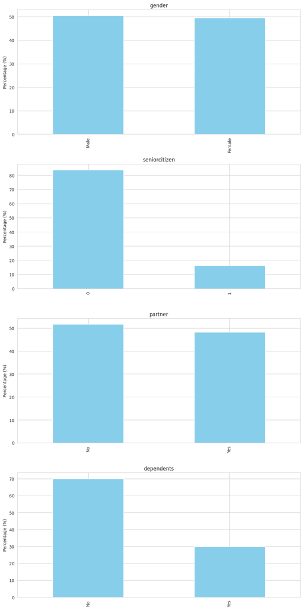

```python
columns = ['gender', 'seniorcitizen', 'partner', 'dependents']

fig, axes = plt.subplots(nrows=len(columns), ncols=1, figsize=(10, 20))

for i, col in enumerate(columns):

    value_counts = personal[col].value_counts(normalize=True) * 100
    value_counts.plot(kind='bar', ax=axes[i], title=col, color='skyblue')
    axes[i].set_ylabel('Percentage (%)')
    axes[i].set_xlabel('')

plt.tight_layout()
plt.show()
```

Пожилые люди: примерно 16,2% подписчиков — пожилые люди. Это свидетельствует о том, что большая часть абонентов (около 83,8%) не попадает в категорию старшего поколения.

Пол: Распределение по полу показывает, что примерно 50,5% подписчиков составляют мужчины, что означает почти равное распределение мужчин и женщин среди подписчиков. Это свидетельствует о хорошем гендерном балансе в выборке.

Партнер: Примерно 48,3% подписчиков указали, что у них есть партнер. Это говорит о том, что распределение между подписчиками с партнерами и без партнеров вполне равномерное, с небольшим уклоном в сторону отсутствия партнера.

Иждивенцы: только около 30% подписчиков имеют иждивенцев. Это показывает, что у большинства подписчиков нет иждивенцев, что может указывать на молодую аудиторию или аудиторию, состоящую из людей среднего возраста, не имеющих детей или других иждивенцев.

На основе исследовательского анализа данных и предварительной обработки «Personal» набора данных:

Набор данных состоит из 7043 записей с четырьмя столбцами: «пол», «пожилой гражданин», «партнер» и «иждивенцы».

Информация о визуализации: Благодаря визуализации мы получили ценную информацию о составе демографической группы набора данных. Например, доля пожилых людей в наборе данных составляет примерно 16,2%, что указывает на меньшинство населения с потенциально разными потребностями и предпочтениями. Распределение по гендерному признаку почти сбалансировано: незначительное большинство клиентов-мужчин. Данные о статусе партнерства и зависимости показывают разнообразную клиентскую базу: менее половины клиентов имеют партнеров или иждивенцев. Эти идеи могут сыграть важную роль в адаптации услуг и маркетинговых стратегий для удовлетворения различных потребностей клиентской базы.

## Датасет **Phone**

В данном датасете необходимо выполнить следующие шаги для исследовательского анализа данных и предобработки: -Перевод названия колонок в нижний регистр, так как это является общепринятой практикой.  
-Поиск пропущенных данных  
-Дубликаты в данном датасете не требуют удаления,так как данные в колонках не носят персонафицированный характер и могут быть одинакомыми для нескольких клиентов  
-Проанализировать распределение категориальных данных

```python
#converting column names to lowercase
phone.columns = phone.columns.str.lower()
```

```python
phone.info()
```

```
<class 'pandas.core.frame.DataFrame'>
RangeIndex: 6361 entries, 0 to 6360
Data columns (total 2 columns):
 #   Column         Non-Null Count  Dtype
---  ------         --------------  -----
 0   customerid     6361 non-null   object
 1   multiplelines  6361 non-null   object
dtypes: object(2)
memory usage: 99.5+ KB
```

```python
phone.head()
```

|  | customerid | multiplelines |
| --- | --- | --- |
| 0 | 5575-GNVDE | No |
| 1 | 3668-QPYBK | No |
| 2 | 9237-HQITU | No |
| 3 | 9305-CDSKC | Yes |
| 4 | 1452-KIOVK | Yes |

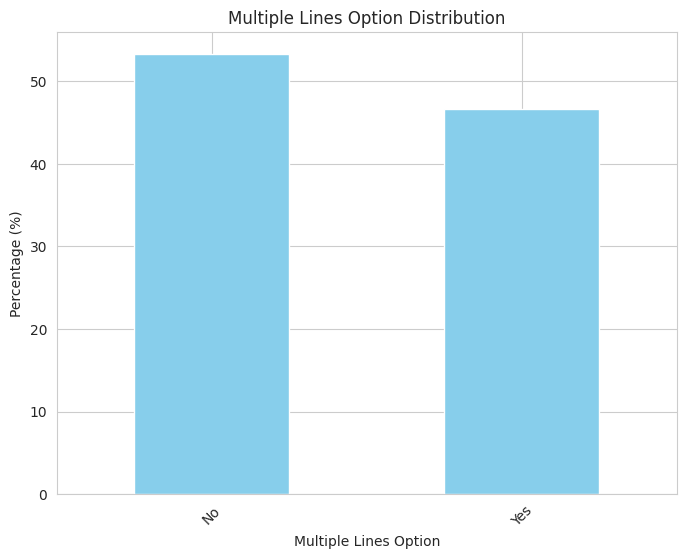

```python
value_counts = phone['multiplelines'].value_counts(normalize=True) * 100

# Visualisation
plt.figure(figsize=(8, 6))
value_counts.plot(kind='bar', color='skyblue')
plt.title('Multiple Lines Option Distribution')
plt.ylabel('Percentage (%)')
plt.xlabel('Multiple Lines Option')
plt.xticks(rotation=45)
plt.show()
```

Данные о функции нескольких линий в наборе телефонных данных иллюстрируют сбалансированное распределение предпочтений клиентов в отношении услуг нескольких линий с небольшим уклоном в сторону отсутствия нескольких линий. Эта информация может быть полезна для понимания потребностей клиентов и соответствующей адаптации услуг или маркетинговых стратегий.

**Вывод по исследовальскому анализу данных (Датасет "Phone")**

Набор данных состоит из 6361 записи с столбцами: «multiplelines».

Столбец «multiplelines» указывает, есть ли у клиента несколько строк (Да) или нет (Нет). Набор данных показывает, что примерно 53,29% клиентов не имеют нескольких линий, а около 46,71% имеют несколько линий. Эта информация дает представление о распределении функций телефонных услуг среди клиентов, что может быть полезно для понимания предпочтений клиентов и оптимизации предложений услуг.

# **Шаг 3 Объединение данных**

```python
# Merge contract с personal
merged_df = contract.merge(personal, on='customerid', how='outer')

# Add data from  internet
merged_df = merged_df.merge(internet, on='customerid', how='outer')

# Add data from phone
final_df = merged_df.merge(phone, on='customerid', how='outer')
```

Для объединения данных в данном случае лучше всего выбрать объединение outer так как этот тип объединения позволяет сохранить полную информацию по всем клиентам, включая тех, кто может быть только в одном из датасетов. Это важно для комплексного анализа клиентской базы, где некоторые клиенты могут пользоваться только определенными услугами.

```python
# Display the first few rows of the DataFrame
display(final_df .head())
```

|  | customerid | begindate | enddate | type | paperlessbilling | paymentmethod | monthlycharges | totalcharges | churn | gender | ... | partner | dependents | internetservice | onlinesecurity | onlinebackup | deviceprotection | techsupport | streamingtv | streamingmovies | multiplelines |
| --- | --- | --- | --- | --- | --- | --- | --- | --- | --- | --- | --- | --- | --- | --- | --- | --- | --- | --- | --- | --- | --- |
| 0 | 7590-VHVEG | 2020-01-01 | 2020-02-01 | Month-to-month | Yes | Electronic check | 29.85 | 31.04 | 0 | Female | ... | Yes | No | DSL | No | Yes | No | No | No | No | NaN |
| 1 | 5575-GNVDE | 2017-04-01 | 2020-02-01 | One year | No | Mailed check | 56.95 | 2071.84 | 0 | Male | ... | No | No | DSL | Yes | No | Yes | No | No | No | No |
| 2 | 3668-QPYBK | 2019-10-01 | 2020-02-01 | Month-to-month | Yes | Mailed check | 53.85 | 226.17 | 0 | Male | ... | No | No | DSL | Yes | Yes | No | No | No | No | No |
| 3 | 7795-CFOCW | 2016-05-01 | 2020-02-01 | One year | No | Bank transfer (automatic) | 42.30 | 1960.60 | 0 | Male | ... | No | No | DSL | Yes | No | Yes | Yes | No | No | NaN |
| 4 | 9237-HQITU | 2019-09-01 | 2020-02-01 | Month-to-month | Yes | Electronic check | 70.70 | 353.50 | 0 | Female | ... | No | No | Fiber optic | No | No | No | No | No | No | No |

5 rows × 21 columns

```python
final_df .info()
```

```
<class 'pandas.core.frame.DataFrame'>
Int64Index: 7043 entries, 0 to 7042
Data columns (total 21 columns):
 #   Column            Non-Null Count  Dtype
---  ------            --------------  -----
 0   customerid        7043 non-null   object
 1   begindate         7043 non-null   datetime64[ns]
 2   enddate           7043 non-null   datetime64[ns]
 3   type              7043 non-null   object
 4   paperlessbilling  7043 non-null   object
 5   paymentmethod     7043 non-null   object
 6   monthlycharges    7043 non-null   float64
 7   totalcharges      7043 non-null   float64
 8   churn             7043 non-null   int64
 9   gender            7043 non-null   object
 10  seniorcitizen     7043 non-null   int64
 11  partner           7043 non-null   object
 12  dependents        7043 non-null   object
 13  internetservice   5517 non-null   object
 14  onlinesecurity    5517 non-null   object
 15  onlinebackup      5517 non-null   object
 16  deviceprotection  5517 non-null   object
 17  techsupport       5517 non-null   object
 18  streamingtv       5517 non-null   object
 19  streamingmovies   5517 non-null   object
 20  multiplelines     6361 non-null   object
dtypes: datetime64[ns](2), float64(2), int64(2), object(15)
memory usage: 1.2+ MB
```

Всего 7043 записи, что соответствует исходному количеству клиентов в датасете contract. Это указывает на то, что каждая запись в датасете contract нашла соответствие хотя бы в одном из других датасетов, или же все записи из contract были сохранены в результате объединения типом outer.  
Присутствие пропусков в данных: Пропуски в столбцах, связанных с интернет-услугами (internetservice, onlinesecurity, onlinebackup, deviceprotection, techsupport, streamingtv, streamingmovies) и телефонными услугами (multiplelines), говорят о том, что не все клиенты пользуются этими услугами. Так, интернет-услугами пользуются 5517 клиентов, а услугами телефонии — 6361 клиент.  
Для дальнейшего анализа необходимо ввести новую переменную -'Длительность контракта' - это позволит понять насколько долго клиенты остаются с компанией.А для дальнейшей работы с данными предполагается создать новый датафрейм и добавить в него только необходимые для анализа колонки.

```python
duplicate_count = final_df.duplicated(subset='customerid', keep=False).sum()
print(duplicate_count)
```

```
0
```

```python
# #assigning a column index
# final_df.set_index('customerid', inplace=True)
```

```python
final_df.info()
```

```
<class 'pandas.core.frame.DataFrame'>
Int64Index: 7043 entries, 0 to 7042
Data columns (total 21 columns):
 #   Column            Non-Null Count  Dtype
---  ------            --------------  -----
 0   customerid        7043 non-null   object
 1   begindate         7043 non-null   datetime64[ns]
 2   enddate           7043 non-null   datetime64[ns]
 3   type              7043 non-null   object
 4   paperlessbilling  7043 non-null   object
 5   paymentmethod     7043 non-null   object
 6   monthlycharges    7043 non-null   float64
 7   totalcharges      7043 non-null   float64
 8   churn             7043 non-null   int64
 9   gender            7043 non-null   object
 10  seniorcitizen     7043 non-null   int64
 11  partner           7043 non-null   object
 12  dependents        7043 non-null   object
 13  internetservice   5517 non-null   object
 14  onlinesecurity    5517 non-null   object
 15  onlinebackup      5517 non-null   object
 16  deviceprotection  5517 non-null   object
 17  techsupport       5517 non-null   object
 18  streamingtv       5517 non-null   object
 19  streamingmovies   5517 non-null   object
 20  multiplelines     6361 non-null   object
dtypes: datetime64[ns](2), float64(2), int64(2), object(15)
memory usage: 1.2+ MB
```

```python
# Calculate the duration of the contract and adding new column
final_df['contract_duration'] = (final_df['enddate'] - final_df['begindate']).dt.days
```

Была вычислена длительность контракта каждого клиента в днях, вычитая дату начала контракта (begindate) из даты его окончания (enddate). Результат был сохранен в новом столбце contract_duration. Это позволяет анализировать, насколько долго клиенты остаются с компанией, что является важным показателем для понимания лояльности клиентов и оттока

```python
final_df.head()
```

|  | customerid | begindate | enddate | type | paperlessbilling | paymentmethod | monthlycharges | totalcharges | churn | gender | ... | dependents | internetservice | onlinesecurity | onlinebackup | deviceprotection | techsupport | streamingtv | streamingmovies | multiplelines | contract_duration |
| --- | --- | --- | --- | --- | --- | --- | --- | --- | --- | --- | --- | --- | --- | --- | --- | --- | --- | --- | --- | --- | --- |
| 0 | 7590-VHVEG | 2020-01-01 | 2020-02-01 | Month-to-month | Yes | Electronic check | 29.85 | 31.04 | 0 | Female | ... | No | DSL | No | Yes | No | No | No | No | NaN | 31 |
| 1 | 5575-GNVDE | 2017-04-01 | 2020-02-01 | One year | No | Mailed check | 56.95 | 2071.84 | 0 | Male | ... | No | DSL | Yes | No | Yes | No | No | No | No | 1036 |
| 2 | 3668-QPYBK | 2019-10-01 | 2020-02-01 | Month-to-month | Yes | Mailed check | 53.85 | 226.17 | 0 | Male | ... | No | DSL | Yes | Yes | No | No | No | No | No | 123 |
| 3 | 7795-CFOCW | 2016-05-01 | 2020-02-01 | One year | No | Bank transfer (automatic) | 42.30 | 1960.60 | 0 | Male | ... | No | DSL | Yes | No | Yes | Yes | No | No | NaN | 1371 |
| 4 | 9237-HQITU | 2019-09-01 | 2020-02-01 | Month-to-month | Yes | Electronic check | 70.70 | 353.50 | 0 | Female | ... | No | Fiber optic | No | No | No | No | No | No | No | 153 |

5 rows × 22 columns

```python
final_df.info()
```

```
<class 'pandas.core.frame.DataFrame'>
Int64Index: 7043 entries, 0 to 7042
Data columns (total 22 columns):
 #   Column             Non-Null Count  Dtype
---  ------             --------------  -----
 0   customerid         7043 non-null   object
 1   begindate          7043 non-null   datetime64[ns]
 2   enddate            7043 non-null   datetime64[ns]
 3   type               7043 non-null   object
 4   paperlessbilling   7043 non-null   object
 5   paymentmethod      7043 non-null   object
 6   monthlycharges     7043 non-null   float64
 7   totalcharges       7043 non-null   float64
 8   churn              7043 non-null   int64
 9   gender             7043 non-null   object
 10  seniorcitizen      7043 non-null   int64
 11  partner            7043 non-null   object
 12  dependents         7043 non-null   object
 13  internetservice    5517 non-null   object
 14  onlinesecurity     5517 non-null   object
 15  onlinebackup       5517 non-null   object
 16  deviceprotection   5517 non-null   object
 17  techsupport        5517 non-null   object
 18  streamingtv        5517 non-null   object
 19  streamingmovies    5517 non-null   object
 20  multiplelines      6361 non-null   object
 21  contract_duration  7043 non-null   int64
dtypes: datetime64[ns](2), float64(2), int64(3), object(15)
memory usage: 1.2+ MB
```

```python
cols = final_df.select_dtypes(include=['object','float']).columns.tolist()
# add manually identified columns
additional_cols = ['churn','contract_duration', 'seniorcitizen']

# Combine lists while ensuring uniqueness
cols = list(set(cols + additional_cols))
df = final_df[cols].copy()
```

В данной ячейке был сформирован список столбцов для дальнейшего анализа, включая категориальные и вещественные переменные, а также важные идентифицированные нами столбцы churn, contract_duration. Это позволяет сфокусироваться на ключевых данных, подготовить их к анализу и моделированию, обеспечивая при этом уникальность и актуальность выборки столбцов

```python
df.info()
```

```
<class 'pandas.core.frame.DataFrame'>
Int64Index: 7043 entries, 0 to 7042
Data columns (total 20 columns):
 #   Column             Non-Null Count  Dtype
---  ------             --------------  -----
 0   type               7043 non-null   object
 1   monthlycharges     7043 non-null   float64
 2   gender             7043 non-null   object
 3   techsupport        5517 non-null   object
 4   internetservice    5517 non-null   object
 5   streamingmovies    5517 non-null   object
 6   onlinebackup       5517 non-null   object
 7   churn              7043 non-null   int64
 8   streamingtv        5517 non-null   object
 9   seniorcitizen      7043 non-null   int64
 10  contract_duration  7043 non-null   int64
 11  onlinesecurity     5517 non-null   object
 12  multiplelines      6361 non-null   object
 13  dependents         7043 non-null   object
 14  deviceprotection   5517 non-null   object
 15  partner            7043 non-null   object
 16  totalcharges       7043 non-null   float64
 17  paymentmethod      7043 non-null   object
 18  paperlessbilling   7043 non-null   object
 19  customerid         7043 non-null   object
dtypes: float64(2), int64(3), object(15)
memory usage: 1.1+ MB
```

## **Вывод**

Наборы данных успешно объединены. После получения комбинации данных необходимо провести предварительную обработку данных. Для этого будут найдены и при необходимости удалены дубликаты. Поскольку большой процент клиентов не подключены к сети, данные о них отключены в Интернете. Все недостающие данные из-за этого будут иметь значение новое введенное значенин Not Applicable. Что касается мультилиний, предположение то же - из-за отсутствия в таблице того, что у клиентов нет мультистрок - пропущенные значения будут заполнены также Not Applicable.

# **Шаг 4. Исследовательский анализ данных и предобработка объединенного датафрейма**

```python
#looking for obvious duplicates
duplicates = df.duplicated(keep=False)


display(df[duplicates])
print(duplicates.sum())
```

|  | type | monthlycharges | gender | techsupport | internetservice | streamingmovies | onlinebackup | churn | streamingtv | seniorcitizen | contract_duration | onlinesecurity | multiplelines | dependents | deviceprotection | partner | totalcharges | paymentmethod | paperlessbilling | customerid |
| --- | --- | --- | --- | --- | --- | --- | --- | --- | --- | --- | --- | --- | --- | --- | --- | --- | --- | --- | --- | --- |

```
0
```

```python
# counting persent of dublicates
duplicates = df.duplicated(keep=False).sum()
percentage_duplicates = (duplicates / len(df)) * 100

print(f"persent of dublicates: {percentage_duplicates}%")
```

```
persent of dublicates: 0.0%
```

```python
# fillimg missing values to multiplelines
df['multiplelines'].fillna('Not Applicable', inplace=True)

# check results
print(df[[ 'multiplelines']].info())
```

```
<class 'pandas.core.frame.DataFrame'>
Int64Index: 7043 entries, 0 to 7042
Data columns (total 1 columns):
 #   Column         Non-Null Count  Dtype
---  ------         --------------  -----
 0   multiplelines  7043 non-null   object
dtypes: object(1)
memory usage: 110.0+ KB
None
```

```python
# Assume missing values indicate no internet service

internet_service_columns = ['internetservice',
    'onlinesecurity', 'onlinebackup', 'deviceprotection',
    'techsupport', 'streamingtv', 'streamingmovies'
]
# Fill missing values

# For columns indicating presence of a service, fill missing values with Not Applicable (service is not provided)
df[internet_service_columns] = df[internet_service_columns].fillna('Not Applicable')


df.info()
```

```
<class 'pandas.core.frame.DataFrame'>
Int64Index: 7043 entries, 0 to 7042
Data columns (total 20 columns):
 #   Column             Non-Null Count  Dtype
---  ------             --------------  -----
 0   type               7043 non-null   object
 1   monthlycharges     7043 non-null   float64
 2   gender             7043 non-null   object
 3   techsupport        7043 non-null   object
 4   internetservice    7043 non-null   object
 5   streamingmovies    7043 non-null   object
 6   onlinebackup       7043 non-null   object
 7   churn              7043 non-null   int64
 8   streamingtv        7043 non-null   object
 9   seniorcitizen      7043 non-null   int64
 10  contract_duration  7043 non-null   int64
 11  onlinesecurity     7043 non-null   object
 12  multiplelines      7043 non-null   object
 13  dependents         7043 non-null   object
 14  deviceprotection   7043 non-null   object
 15  partner            7043 non-null   object
 16  totalcharges       7043 non-null   float64
 17  paymentmethod      7043 non-null   object
 18  paperlessbilling   7043 non-null   object
 19  customerid         7043 non-null   object
dtypes: float64(2), int64(3), object(15)
memory usage: 1.1+ MB
```

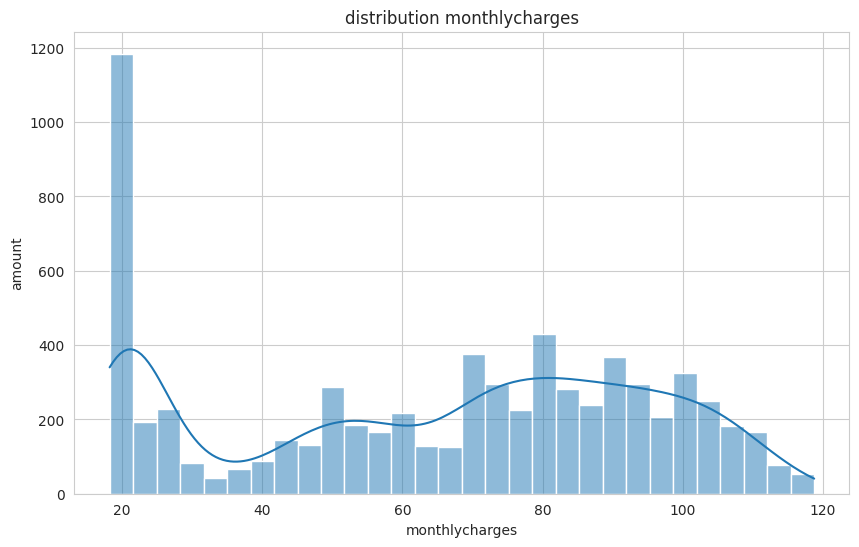

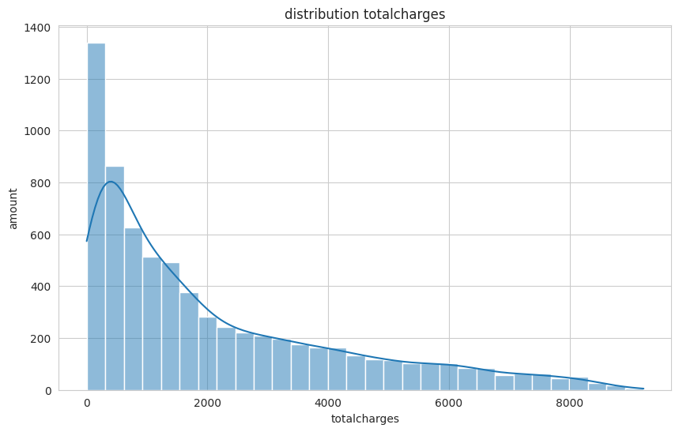

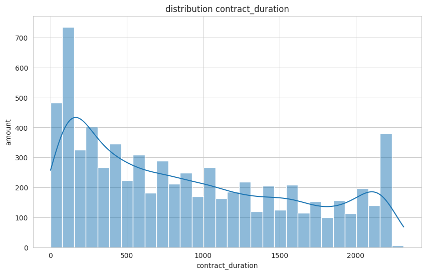

```python
# Visualisation of numeric features
num_features = ['monthlycharges', 'totalcharges', 'contract_duration']
for feature in num_features:
    plt.figure(figsize=(10, 6))
    sns.histplot(df[feature], kde=True, bins=30)
    plt.title(f'distribution {feature}')
    plt.xlabel(feature)
    plt.ylabel('amount')
    plt.show()
```

```python
df.info()
```

```
<class 'pandas.core.frame.DataFrame'>
Int64Index: 7043 entries, 0 to 7042
Data columns (total 20 columns):
 #   Column             Non-Null Count  Dtype
---  ------             --------------  -----
 0   type               7043 non-null   object
 1   monthlycharges     7043 non-null   float64
 2   gender             7043 non-null   object
 3   techsupport        7043 non-null   object
 4   internetservice    7043 non-null   object
 5   streamingmovies    7043 non-null   object
 6   onlinebackup       7043 non-null   object
 7   churn              7043 non-null   int64
 8   streamingtv        7043 non-null   object
 9   seniorcitizen      7043 non-null   int64
 10  contract_duration  7043 non-null   int64
 11  onlinesecurity     7043 non-null   object
 12  multiplelines      7043 non-null   object
 13  dependents         7043 non-null   object
 14  deviceprotection   7043 non-null   object
 15  partner            7043 non-null   object
 16  totalcharges       7043 non-null   float64
 17  paymentmethod      7043 non-null   object
 18  paperlessbilling   7043 non-null   object
 19  customerid         7043 non-null   object
dtypes: float64(2), int64(3), object(15)
memory usage: 1.1+ MB
```

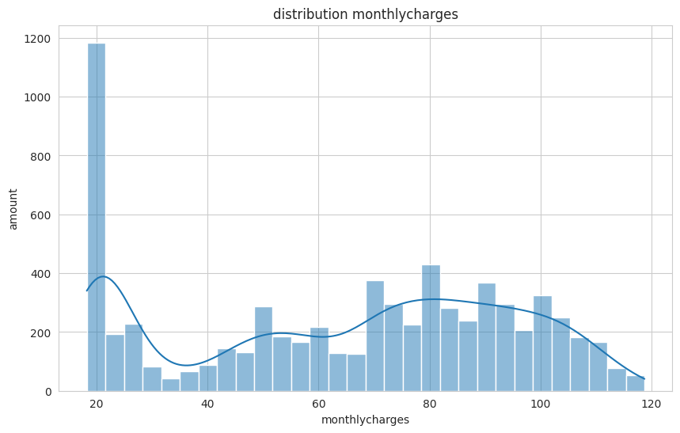

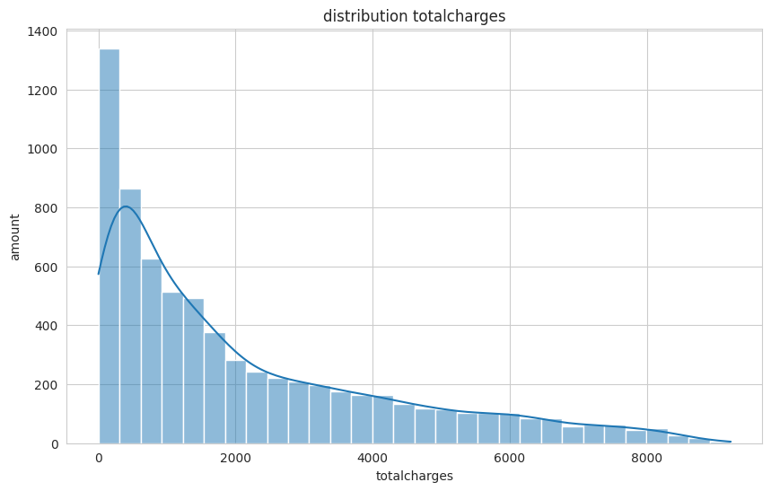

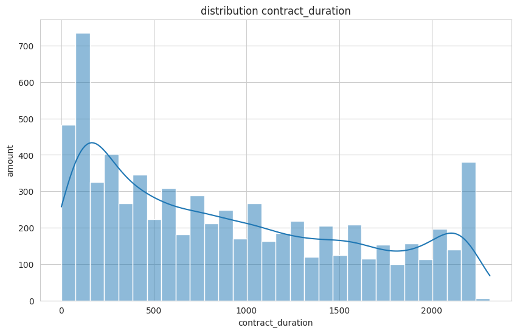

```python
# Visualisation of numeric features
num_features = ['monthlycharges', 'totalcharges','contract_duration' ]
for feature in num_features:
    plt.figure(figsize=(10, 6))
    sns.histplot(df[feature], kde=True, bins=30)
    plt.title(f'distribution {feature}')
    plt.xlabel(feature)
    plt.ylabel('amount')
    plt.show()
```

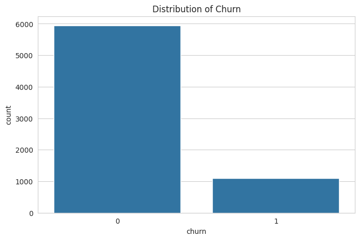

```python
#Distribution of Churn
plt.figure(figsize=(8, 5))
sns.countplot(x='churn', data=df)
plt.title('Distribution of Churn')
plt.show()
```

Для целевой переменной существует большой дисбаланс классов. Однако выбранная метрика оценки — площадь под ROC-кривой — является устойчивой к дисбалансу классов. Это делает ROC-AUC подходящей метрикой позволяя сосредоточиться на улучшении способности модели различать классы, а не только на точности предсказаний.

```python
df_for_phik = df.drop(columns=['customerid'])

# Specify your interval columns. For example, 'monthlycharges' and 'totalcharges' are numerical.
interval_columns = ['monthlycharges', 'totalcharges', 'contract_duration']

# Calculate the phik correlation matrix
phik_matrix = df_for_phik.phik_matrix(interval_cols=interval_columns)

# Extract the 'churn' column to get correlations with 'churn' only
churn_correlation = phik_matrix['churn'].sort_values(ascending=False)


churn_correlation = churn_correlation.drop('customerid', errors='ignore')

# Print the correlation of 'churn' with all other variables
print(churn_correlation)

# # Visualize the phik correlation matrix
# plt.figure(figsize=(12, 10))
# sns.heatmap(phik_matrix.drop(index=['customerid'], columns=['customerid'], errors='ignore'), annot=True, fmt=".2f", cmap='coolwarm', square=True)
# plt.title("Phik Correlation Matrix")
# plt.show()
```

```
churn                1.000000
contract_duration    0.374569
totalcharges         0.302890
partner              0.226688
monthlycharges       0.225925
paymentmethod        0.214832
multiplelines        0.105101
type                 0.094015
onlinebackup         0.089704
streamingmovies      0.086577
seniorcitizen        0.086159
deviceprotection     0.085608
paperlessbilling     0.083398
streamingtv          0.078545
onlinesecurity       0.058659
internetservice      0.056621
techsupport          0.051537
dependents           0.046871
gender               0.008581
Name: churn, dtype: float64
```

```python
# display(phik_matrix)
```

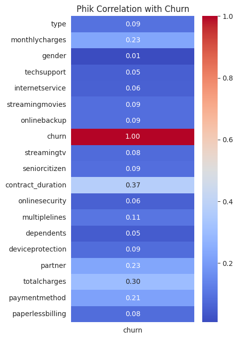

```python
churn_correlation_df = phik_matrix[['churn']].drop(index=['customerid'], errors='ignore')

# Визуализация тепловой карты для корреляций churn
plt.figure(figsize=(4, 8)) # Размер фигуры адаптирован под один столбец
sns.heatmap(churn_correlation_df, annot=True, fmt=".2f", cmap='coolwarm', cbar=True)
plt.title("Phik Correlation with Churn")
plt.show()
```

Эти выводы подчеркивают значимость определенных услуг и условий контракта для удержания клиентов и могут служить основой для разработки стратегий по снижению оттока, например, путем предложения более привлекательных условий для долгосрочных контрактов, оптимизации ценообразования и улучшения условий оплаты.

```python
# Разделение датасета на две части: ушли (churn = 1) и остались (churn = 0)
df_churned = df[df['churn'] == 1]
df_stayed = df[df['churn'] == 0]

# Вычисление матрицы корреляции phi_k для клиентов, которые ушли
phik_matrix_churned = df_churned.phik_matrix(interval_cols=interval_columns)

# Вычисление матрицы корреляции phi_k для клиентов, которые остались
phik_matrix_stayed = df_stayed.phik_matrix(interval_cols=interval_columns)
```

```python
display(phik_matrix_churned )
```

|  | type | monthlycharges | gender | techsupport | internetservice | streamingmovies | onlinebackup | streamingtv | seniorcitizen | contract_duration | onlinesecurity | multiplelines | dependents | deviceprotection | partner | totalcharges | paymentmethod | paperlessbilling | customerid |
| --- | --- | --- | --- | --- | --- | --- | --- | --- | --- | --- | --- | --- | --- | --- | --- | --- | --- | --- | --- |
| type | 1.000000 | 0.446097 | 0.000000 | 0.731526 | 0.661150 | 0.588044 | 0.624364 | 0.593058 | 0.150255 | 0.345464 | 0.694019 | 0.222025 | 0.133679 | 0.640437 | 0.109104 | 0.148812 | 0.274423 | 0.140886 | 1.0 |
| monthlycharges | 0.446097 | 1.000000 | 0.000000 | 0.824158 | 0.926400 | 0.857179 | 0.813834 | 0.861663 | 0.246699 | 0.090915 | 0.818126 | 0.745268 | 0.260374 | 0.821914 | 0.112994 | 0.665053 | 0.360215 | 0.455673 | 1.0 |
| gender | 0.000000 | 0.000000 | 1.000000 | 0.000000 | 0.000000 | 0.000000 | 0.000000 | 0.000000 | 0.000000 | 0.012534 | 0.030838 | 0.000000 | 0.000000 | 0.000000 | 0.000000 | 0.000000 | 0.000000 | 0.000000 | 1.0 |
| techsupport | 0.731526 | 0.824158 | 0.000000 | 1.000000 | 0.951404 | 0.943127 | 0.944160 | 0.942993 | 0.131613 | 0.142948 | 0.952579 | 0.486278 | 0.116841 | 0.944586 | 0.042786 | 0.549521 | 0.255358 | 0.187548 | 1.0 |
| internetservice | 0.661150 | 0.926400 | 0.000000 | 0.951404 | 1.000000 | 0.945753 | 0.942944 | 0.946636 | 0.141255 | 0.079151 | 0.951250 | 0.743312 | 0.130016 | 0.943294 | 0.044135 | 0.577567 | 0.289629 | 0.212205 | 1.0 |
| streamingmovies | 0.588044 | 0.857179 | 0.000000 | 0.943127 | 0.945753 | 1.000000 | 0.942797 | 0.960473 | 0.107008 | 0.079623 | 0.943431 | 0.517245 | 0.115524 | 0.947671 | 0.064703 | 0.567665 | 0.240827 | 0.196095 | 1.0 |
| onlinebackup | 0.624364 | 0.813834 | 0.000000 | 0.944160 | 0.942944 | 0.942797 | 1.000000 | 0.942712 | 0.106845 | 0.202700 | 0.944006 | 0.488431 | 0.114802 | 0.944109 | 0.056737 | 0.564988 | 0.241599 | 0.182297 | 1.0 |
| streamingtv | 0.593058 | 0.861663 | 0.000000 | 0.942993 | 0.946636 | 0.960473 | 0.942712 | 1.000000 | 0.106664 | 0.069216 | 0.943437 | 0.513932 | 0.116847 | 0.946655 | 0.058371 | 0.574844 | 0.246380 | 0.199515 | 1.0 |
| seniorcitizen | 0.150255 | 0.246699 | 0.000000 | 0.131613 | 0.141255 | 0.107008 | 0.106845 | 0.106664 | 1.000000 | 0.000000 | 0.126571 | 0.067585 | 0.387737 | 0.107220 | 0.000000 | 0.120960 | 0.255006 | 0.232915 | 1.0 |
| contract_duration | 0.345464 | 0.090915 | 0.012534 | 0.142948 | 0.079151 | 0.079623 | 0.202700 | 0.069216 | 0.000000 | 1.000000 | 0.161145 | 0.136825 | 0.046851 | 0.133781 | 0.108645 | 0.837747 | 0.164580 | 0.000000 | 1.0 |
| onlinesecurity | 0.694019 | 0.818126 | 0.030838 | 0.952579 | 0.951250 | 0.943431 | 0.944006 | 0.943437 | 0.126571 | 0.161145 | 1.000000 | 0.489840 | 0.127504 | 0.943810 | 0.068862 | 0.545258 | 0.283102 | 0.201340 | 1.0 |
| multiplelines | 0.222025 | 0.745268 | 0.000000 | 0.486278 | 0.743312 | 0.517245 | 0.488431 | 0.513932 | 0.067585 | 0.136825 | 0.489840 | 1.000000 | 0.061423 | 0.499953 | 0.000000 | 0.371234 | 0.183212 | 0.076510 | 1.0 |
| dependents | 0.133679 | 0.260374 | 0.000000 | 0.116841 | 0.130016 | 0.115524 | 0.114802 | 0.116847 | 0.387737 | 0.046851 | 0.127504 | 0.061423 | 1.000000 | 0.115920 | 0.546074 | 0.073753 | 0.253760 | 0.167624 | 1.0 |
| deviceprotection | 0.640437 | 0.821914 | 0.000000 | 0.944586 | 0.943294 | 0.947671 | 0.944109 | 0.946655 | 0.107220 | 0.133781 | 0.943810 | 0.499953 | 0.115920 | 1.000000 | 0.084173 | 0.550676 | 0.240360 | 0.182645 | 1.0 |
| partner | 0.109104 | 0.112994 | 0.000000 | 0.042786 | 0.044135 | 0.064703 | 0.056737 | 0.058371 | 0.000000 | 0.108645 | 0.068862 | 0.000000 | 0.546074 | 0.084173 | 1.000000 | 0.053685 | 0.134988 | 0.035067 | 1.0 |
| totalcharges | 0.148812 | 0.665053 | 0.000000 | 0.549521 | 0.577567 | 0.567665 | 0.564988 | 0.574844 | 0.120960 | 0.837747 | 0.545258 | 0.371234 | 0.073753 | 0.550676 | 0.053685 | 1.000000 | 0.248341 | 0.254837 | 1.0 |
| paymentmethod | 0.274423 | 0.360215 | 0.000000 | 0.255358 | 0.289629 | 0.240827 | 0.241599 | 0.246380 | 0.255006 | 0.164580 | 0.283102 | 0.183212 | 0.253760 | 0.240360 | 0.134988 | 0.248341 | 1.000000 | 0.347812 | 1.0 |
| paperlessbilling | 0.140886 | 0.455673 | 0.000000 | 0.187548 | 0.212205 | 0.196095 | 0.182297 | 0.199515 | 0.232915 | 0.000000 | 0.201340 | 0.076510 | 0.167624 | 0.182645 | 0.035067 | 0.254837 | 0.347812 | 1.000000 | 1.0 |
| customerid | 1.000000 | 1.000000 | 1.000000 | 1.000000 | 1.000000 | 1.000000 | 1.000000 | 1.000000 | 1.000000 | 1.000000 | 1.000000 | 1.000000 | 1.000000 | 1.000000 | 1.000000 | 1.000000 | 1.000000 | 1.000000 | 1.0 |

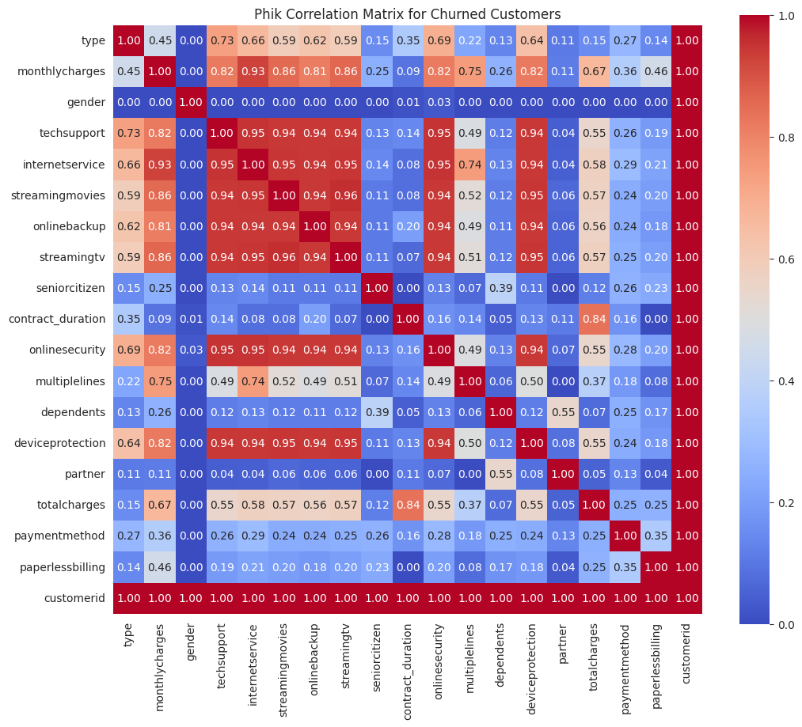

```python
# Визуализация матрицы корреляции phi_k для клиентов, которые ушли
plt.figure(figsize=(12, 10))
sns.heatmap(phik_matrix_churned, annot=True, fmt=".2f", cmap='coolwarm', square=True)
plt.title("Phik Correlation Matrix for Churned Customers")
plt.show()
```

Из таблицы корреляции между различными признаками и оттоком клиентов (churn) можно сделать следующие выводы:

1. **Продолжительность контракта** ((0.837747)) имеет высокую корреляцию с общими расходами (totalcharges), что указывает на то, что клиенты с более длительными контрактами склонны иметь более высокие общие расходы. Это может свидетельствовать о более высокой лояльности и удовлетворенности услугами.
2. **Интернет-услуга** ((0.926400)) и **ежемесячные платежи** ((1.000000)) показывают весьма высокую корреляцию, подчеркивая, что выбор интернет-услуги значительно влияет на размер ежемесячных платежей клиентов.
3. **Онлайн-безопасность** ((0.818126)), **техподдержка** ((0.824158)), и **защита устройства** ((0.821914)) также демонстрируют высокую корреляцию с ежемесячными платежами, что может указывать на то, что клиенты, использующие эти услуги, склонны платить больше каждый месяц.
4. Важно отметить, что **пол** (gender) и **наличие партнера** (partner) показывают нулевую или очень слабую корреляцию с большинством других признаков, что говорит о том, что эти демографические признаки имеют ограниченное влияние на использование и оплату услуг.
5. **Стриминговые сервисы** (streamingtv и streamingmovies) имеют весьма высокую корреляцию между собой ((0.960473)) и с ежемесячными платежами, подчеркивая популярность и влияние этих услуг на общую стоимость услуг для клиентов.

```python
display(phik_matrix_stayed)
```

|  | type | monthlycharges | gender | techsupport | internetservice | streamingmovies | onlinebackup | streamingtv | seniorcitizen | contract_duration | onlinesecurity | multiplelines | dependents | deviceprotection | partner | totalcharges | paymentmethod | paperlessbilling | customerid |
| --- | --- | --- | --- | --- | --- | --- | --- | --- | --- | --- | --- | --- | --- | --- | --- | --- | --- | --- | --- |
| type | 1.000000 | 0.396109 | 0.000000 | 0.667940 | 0.499595 | 0.558627 | 0.580416 | 0.553192 | 0.080433 | 0.673949 | 0.633664 | 0.266735 | 0.148631 | 0.636085 | 0.180417 | 0.510627 | 0.275639 | 0.108187 | 1.0 |
| monthlycharges | 0.396109 | 1.000000 | 0.000000 | 0.816466 | 0.919406 | 0.864061 | 0.819569 | 0.864816 | 0.308421 | 0.430846 | 0.812664 | 0.704083 | 0.189511 | 0.827215 | 0.210001 | 0.743925 | 0.401913 | 0.467430 | 1.0 |
| gender | 0.000000 | 0.000000 | 1.000000 | 0.000000 | 0.000000 | 0.007930 | 0.008068 | 0.000000 | 0.000000 | 0.000000 | 0.000000 | 0.000000 | 0.000000 | 0.000000 | 0.000000 | 0.000000 | 0.000000 | 0.009251 | 1.0 |
| techsupport | 0.667940 | 0.816466 | 0.000000 | 1.000000 | 0.948669 | 0.947063 | 0.948370 | 0.947153 | 0.135363 | 0.379625 | 0.952421 | 0.540354 | 0.113674 | 0.951453 | 0.084855 | 0.534114 | 0.324495 | 0.200995 | 1.0 |
| internetservice | 0.499595 | 0.919406 | 0.000000 | 0.948669 | 1.000000 | 0.945999 | 0.942855 | 0.946357 | 0.162217 | 0.041286 | 0.949509 | 0.733546 | 0.108033 | 0.942804 | 0.000000 | 0.484988 | 0.326352 | 0.232406 | 1.0 |
| streamingmovies | 0.558627 | 0.864061 | 0.007930 | 0.947063 | 0.945999 | 1.000000 | 0.945366 | 0.965290 | 0.112163 | 0.330746 | 0.943536 | 0.581853 | 0.082092 | 0.953959 | 0.071895 | 0.557269 | 0.286097 | 0.200733 | 1.0 |
| onlinebackup | 0.580416 | 0.819569 | 0.008068 | 0.948370 | 0.942855 | 0.945366 | 1.000000 | 0.946038 | 0.108480 | 0.389379 | 0.947579 | 0.560202 | 0.098716 | 0.947376 | 0.091151 | 0.555652 | 0.294983 | 0.195295 | 1.0 |
| streamingtv | 0.553192 | 0.864816 | 0.000000 | 0.947153 | 0.946357 | 0.965290 | 0.946038 | 1.000000 | 0.110102 | 0.329878 | 0.943301 | 0.583081 | 0.084876 | 0.953353 | 0.080578 | 0.557386 | 0.286328 | 0.203048 | 1.0 |
| seniorcitizen | 0.080433 | 0.308421 | 0.000000 | 0.135363 | 0.162217 | 0.112163 | 0.108480 | 0.110102 | 1.000000 | 0.041198 | 0.126872 | 0.087220 | 0.313729 | 0.108813 | 0.013593 | 0.128194 | 0.295357 | 0.238049 | 1.0 |
| contract_duration | 0.673949 | 0.430846 | 0.000000 | 0.379625 | 0.041286 | 0.330746 | 0.389379 | 0.329878 | 0.041198 | 1.000000 | 0.373044 | 0.370549 | 0.212115 | 0.405705 | 0.486938 | 0.844546 | 0.369959 | 0.023460 | 1.0 |
| onlinesecurity | 0.633664 | 0.812664 | 0.000000 | 0.952421 | 0.949509 | 0.943536 | 0.947579 | 0.943301 | 0.126872 | 0.373044 | 1.000000 | 0.540216 | 0.118221 | 0.947124 | 0.093232 | 0.522232 | 0.316058 | 0.208145 | 1.0 |
| multiplelines | 0.266735 | 0.704083 | 0.000000 | 0.540354 | 0.733546 | 0.581853 | 0.560202 | 0.583081 | 0.087220 | 0.370549 | 0.540216 | 1.000000 | 0.011428 | 0.559531 | 0.082226 | 0.478160 | 0.165839 | 0.098622 | 1.0 |
| dependents | 0.148631 | 0.189511 | 0.000000 | 0.113674 | 0.108033 | 0.082092 | 0.098716 | 0.084876 | 0.313729 | 0.212115 | 0.118221 | 0.011428 | 1.000000 | 0.093425 | 0.670497 | 0.096771 | 0.218618 | 0.175547 | 1.0 |
| deviceprotection | 0.636085 | 0.827215 | 0.000000 | 0.951453 | 0.942804 | 0.953959 | 0.947376 | 0.953353 | 0.108813 | 0.405705 | 0.947124 | 0.559531 | 0.093425 | 1.000000 | 0.095270 | 0.568247 | 0.301629 | 0.195912 | 1.0 |
| partner | 0.180417 | 0.210001 | 0.000000 | 0.084855 | 0.000000 | 0.071895 | 0.091151 | 0.080578 | 0.013593 | 0.486938 | 0.093232 | 0.082226 | 0.670497 | 0.095270 | 1.000000 | 0.411492 | 0.231568 | 0.024052 | 1.0 |
| totalcharges | 0.510627 | 0.743925 | 0.000000 | 0.534114 | 0.484988 | 0.557269 | 0.555652 | 0.557386 | 0.128194 | 0.844546 | 0.522232 | 0.478160 | 0.096771 | 0.568247 | 0.411492 | 1.000000 | 0.342623 | 0.188347 | 1.0 |
| paymentmethod | 0.275639 | 0.401913 | 0.000000 | 0.324495 | 0.326352 | 0.286097 | 0.294983 | 0.286328 | 0.295357 | 0.369959 | 0.316058 | 0.165839 | 0.218618 | 0.301629 | 0.231568 | 0.342623 | 1.000000 | 0.370741 | 1.0 |
| paperlessbilling | 0.108187 | 0.467430 | 0.009251 | 0.200995 | 0.232406 | 0.200733 | 0.195295 | 0.203048 | 0.238049 | 0.023460 | 0.208145 | 0.098622 | 0.175547 | 0.195912 | 0.024052 | 0.188347 | 0.370741 | 1.000000 | 1.0 |
| customerid | 1.000000 | 1.000000 | 1.000000 | 1.000000 | 1.000000 | 1.000000 | 1.000000 | 1.000000 | 1.000000 | 1.000000 | 1.000000 | 1.000000 | 1.000000 | 1.000000 | 1.000000 | 1.000000 | 1.000000 | 1.000000 | 1.0 |

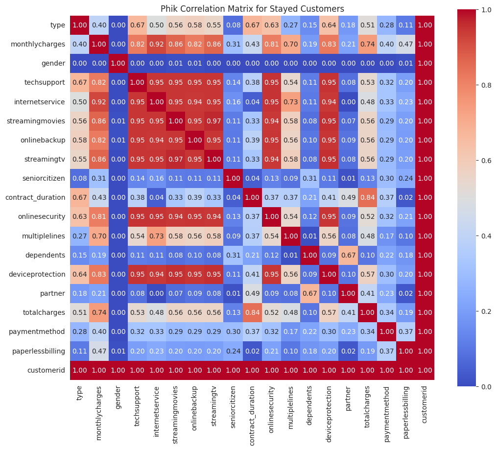

```python
# Визуализация матрицы корреляции phi_k для клиентов, которые остались
plt.figure(figsize=(12, 10))
sns.heatmap(phik_matrix_stayed, annot=True, fmt=".2f", cmap='coolwarm', square=True)
plt.title("Phik Correlation Matrix for Stayed Customers")
plt.show()
```

Из таблицы корреляции для группы клиентов, которые остались, можно сделать следующие ключевые выводы:

1. **Продолжительность контракта** ((0.844546)) продолжает демонстрировать высокую корреляцию с общими расходами (totalcharges), что подтверждает, что клиенты с более длительными контрактами, как правило, накапливают больше расходов за время использования услуг. Это указывает на долгосрочную вовлеченность и возможно большую лояльность среди оставшихся клиентов.
2. **Ежемесячные платежи** ((0.743925)) имеют высокую корреляцию с общими расходами, что свидетельствует о том, что регулярные ежемесячные платежи значительно способствуют общему объему расходов клиентов. Это подчеркивает важность управления ежемесячными платежами для поддержания удовлетворенности клиентов.
3. **Интернет-услуги** ((0.484988)) и **многоканальная связь** (multiplelines) ((0.478160)) показывают умеренную корреляцию с общими расходами, что может отражать популярность и ценность этих услуг среди оставшихся клиентов.
4. **Онлайн-безопасность** ((0.522232)), **техподдержка** ((0.534114)), и **защита устройства** ((0.568247)) показывают заметную корреляцию с общими расходами, подчеркивая, что дополнительные услуги в области безопасности и поддержки важны для клиентов, что может способствовать их решению остаться.
5. **Партнер** ((0.411492)) показывает умеренную корреляцию с общими расходами, что может указывать на то, что наличие партнера влияет на решение остаться с компанией, возможно, из-за совместного использования услуг или лучших условий для семейных планов.
6. **Стриминговые услуги** (streamingtv и streamingmovies) демонстрируют весьма высокую корреляцию друг с другом и с ежемесячными платежами, что подтверждает их популярность и вклад в общую стоимость услуг среди оставшихся клиентов.

Сравнительный вывод корреляций между ушедшими и оставшимися клиентами:

Сравнивая корреляции между ушедшими и оставшимися клиентами, можно выявить несколько ключевых различий и сходств, которые помогают лучше понять факторы, влияющие на отток клиентов:

Сходства:

- **Продолжительность контракта** и **общие расходы** показывают высокую корреляцию в обеих группах, что подчеркивает их важность в контексте общей вовлеченности клиентов и накопления расходов во времени. Это указывает на то, что независимо от решения оставаться или уйти, эти два фактора имеют значительное влияние на финансовые взаимоотношения клиентов с компанией.

# **Шаг 5 Подготовка данных**

```python
df.info()
```

```
<class 'pandas.core.frame.DataFrame'>
Int64Index: 7043 entries, 0 to 7042
Data columns (total 20 columns):
 #   Column             Non-Null Count  Dtype
---  ------             --------------  -----
 0   type               7043 non-null   object
 1   monthlycharges     7043 non-null   float64
 2   gender             7043 non-null   object
 3   techsupport        7043 non-null   object
 4   internetservice    7043 non-null   object
 5   streamingmovies    7043 non-null   object
 6   onlinebackup       7043 non-null   object
 7   churn              7043 non-null   int64
 8   streamingtv        7043 non-null   object
 9   seniorcitizen      7043 non-null   int64
 10  contract_duration  7043 non-null   int64
 11  onlinesecurity     7043 non-null   object
 12  multiplelines      7043 non-null   object
 13  dependents         7043 non-null   object
 14  deviceprotection   7043 non-null   object
 15  partner            7043 non-null   object
 16  totalcharges       7043 non-null   float64
 17  paymentmethod      7043 non-null   object
 18  paperlessbilling   7043 non-null   object
 19  customerid         7043 non-null   object
dtypes: float64(2), int64(3), object(15)
memory usage: 1.1+ MB
```

```python
print(df['seniorcitizen'].value_counts())
```

```
0    5901
1    1142
Name: seniorcitizen, dtype: int64
```

```python
print(df['seniorcitizen'].dtype)
```

```
int64
```

```python
df['seniorcitizen'] = df['seniorcitizen'].astype(str)
```

Преобразование seniorcitizen в строку: Это шаг необходим для унификации типов данных перед их обработкой. Поскольку seniorcitizen изначально является числовым признаком, представляющим бинарную категорию (0 или 1), его преобразование в строковый формат позволяет более эффективно применять к нему методы кодирования категориальных признаков, такие как One-Hot Encoding.

Установка customerid в качестве индекса

```python
df.set_index('customerid', inplace=True)
```

```python
# Assuming df_final DataFrame and 'churn' is the target variable
X = df.drop(['churn'], axis=1)  # Drop target variable
y = df['churn']
```

```python
# Splitting the dataset into the Training set and Test set
X_train, X_test, y_train, y_test = train_test_split(X, y, test_size=0.25, random_state=RANDOM_STATE)

# Identifying numeric and categorical features
numeric_features = X_train.select_dtypes(include=['int64', 'float64']).columns
categorical_features = X_train.select_dtypes(include=['object']).columns

# Creating transformers for the preprocessing pipeline
numeric_transformer = Pipeline(steps=[
    ('scaler', StandardScaler())  # Scaling numeric features
])

categorical_transformer = Pipeline(steps=[
    ('onehot', OneHotEncoder(drop='first'))  # One-hot encoding categorical features, dropping the first column
])

# Combining transformers into a ColumnTransformer
preprocessor = ColumnTransformer(
    transformers=[
        ('num', numeric_transformer, numeric_features),
        ('cat', categorical_transformer, categorical_features)
    ])

# Applying the transformations to the training and test sets
X_train_transformed = preprocessor.fit_transform(X_train)
X_test_transformed = preprocessor.transform(X_test)

# Extracting new column names for the transformed features
new_numeric_features = numeric_features.tolist()
# new_categorical_features = preprocessor.named_transformers_['cat'].get_feature_names_out(categorical_features)
new_categorical_features = preprocessor.named_transformers_['cat'].named_steps['onehot'].get_feature_names_out()

# Combining all new feature names
all_new_features = new_numeric_features + new_categorical_features.tolist()

# Convert the transformed features back to DataFrame for readability (optional)
X_train_transformed_df = pd.DataFrame(X_train_transformed, columns=all_new_features, index=X_train.index)
X_test_transformed_df = pd.DataFrame(X_test_transformed, columns=all_new_features, index=X_test.index)
```

```python
display(X_train_transformed_df.head())
```

| customerid | monthlycharges | contract_duration | totalcharges | type_One year | type_Two year | gender_Male | techsupport_Not Applicable | techsupport_Yes | internetservice_Fiber optic | internetservice_Not Applicable | ... | multiplelines_Not Applicable | multiplelines_Yes | dependents_Yes | deviceprotection_Not Applicable | deviceprotection_Yes | partner_Yes | paymentmethod_Credit card (automatic) | paymentmethod_Electronic check | paymentmethod_Mailed check | paperlessbilling_Yes |
| --- | --- | --- | --- | --- | --- | --- | --- | --- | --- | --- | --- | --- | --- | --- | --- | --- | --- | --- | --- | --- | --- |
| 2560-PPCHE | 1.339649 | -0.864882 | -0.461626 | 1.0 | 0.0 | 0.0 | 0.0 | 1.0 | 1.0 | 0.0 | ... | 0.0 | 1.0 | 0.0 | 0.0 | 0.0 | 0.0 | 0.0 | 0.0 | 0.0 | 1.0 |
| 6583-QGCSI | 0.774381 | 0.732455 | 1.065471 | 0.0 | 0.0 | 0.0 | 0.0 | 0.0 | 1.0 | 0.0 | ... | 0.0 | 1.0 | 0.0 | 0.0 | 0.0 | 1.0 | 0.0 | 1.0 | 0.0 | 1.0 |
| 6898-MDLZW | -0.366129 | -0.774604 | -0.683254 | 0.0 | 0.0 | 1.0 | 0.0 | 1.0 | 0.0 | 0.0 | ... | 0.0 | 0.0 | 0.0 | 0.0 | 0.0 | 0.0 | 0.0 | 0.0 | 1.0 | 1.0 |
| 5171-EPLKN | -1.493339 | -0.109168 | -0.743776 | 0.0 | 1.0 | 1.0 | 1.0 | 0.0 | 0.0 | 1.0 | ... | 0.0 | 0.0 | 0.0 | 1.0 | 0.0 | 0.0 | 1.0 | 0.0 | 0.0 | 0.0 |
| 6646-JPPHA | 0.468472 | -0.684326 | -0.455253 | 0.0 | 0.0 | 0.0 | 0.0 | 0.0 | 1.0 | 0.0 | ... | 0.0 | 0.0 | 0.0 | 0.0 | 0.0 | 0.0 | 0.0 | 1.0 | 0.0 | 0.0 |

5 rows × 29 columns

```python
X_train_transformed_df.info()
```

```
<class 'pandas.core.frame.DataFrame'>
Index: 5282 entries, 2560-PPCHE to 4791-QRGMF
Data columns (total 29 columns):
 #   Column                                 Non-Null Count  Dtype
---  ------                                 --------------  -----
 0   monthlycharges                         5282 non-null   float64
 1   contract_duration                      5282 non-null   float64
 2   totalcharges                           5282 non-null   float64
 3   type_One year                          5282 non-null   float64
 4   type_Two year                          5282 non-null   float64
 5   gender_Male                            5282 non-null   float64
 6   techsupport_Not Applicable             5282 non-null   float64
 7   techsupport_Yes                        5282 non-null   float64
 8   internetservice_Fiber optic            5282 non-null   float64
 9   internetservice_Not Applicable         5282 non-null   float64
```

[output cut: 21 more lines]

Данные для обучения модели подготовлены. Данные были разделены на две выборки, проведено масштабирование числовых признаков и кодирование категориальных с учетом особенностей данных и моделей.

В процессе подготовки данных для моделирования были выполнены следующие ключевые шаги:

1. **Преобразование переменной seniorcitizen в строковый тип**: Это позволяет обрабатывать бинарный признак как категориальный, упрощая последующее кодирование и анализ.
2. **Разделение на обучающую и тестовую выборки**: Использование 75% данных для обучения и 25% для тестирования обеспечивает баланс между тренировкой модели и оценкой ее производительности на новых данных.
3. **Идентификация и обработка признаков**:
   - **Числовые признаки** масштабируются с помощью StandardScaler для улучшения производительности модели, нормализуя распределение данных.
   - **Категориальные признаки** преобразуются через OneHotEncoder, что позволяет модели корректно интерпретировать категории без предположений о их порядке или величине.
4. **Применение предобработки**: Обучение преобразований на обучающей выборке и их применение к тестовой выборке гарантирует, что данные обрабатываются правильно, что критически важно для точности модели.

Эти шаги необходимы для эффективной подготовки данных, что обеспечивает адекватность и точность последующего моделирования.

# **Шаг 6: Машинное обучение моделей**

Training model CatBoost

```python
param_dist = {
     'iterations': [100, 500, 1000],
    'learning_rate': uniform(0.01, 0.3),
    'depth': [4, 6, 8, 10]}


# Inisialization model CatBoostClassifier
catboost_model = CatBoostClassifier(verbose=False, eval_metric='AUC', loss_function='Logloss', random_seed=RANDOM_STATE)

#  RandomizedSearchCV
random_search = RandomizedSearchCV(catboost_model, param_distributions=param_dist, n_iter=10, scoring='roc_auc', cv=3, random_state=RANDOM_STATE, verbose=2)

# fit model with RandomizedSearchCV
random_search.fit(X_train_transformed_df, y_train)
```

```
Fitting 3 folds for each of 10 candidates, totalling 30 fits
[CV] END depth=10, iterations=100, learning_rate=0.22317596425688302; total time=   3.7s
[CV] END depth=10, iterations=100, learning_rate=0.22317596425688302; total time=   4.4s
[CV] END depth=10, iterations=100, learning_rate=0.22317596425688302; total time=   2.8s
[CV] END depth=4, iterations=1000, learning_rate=0.11187815841373282; total time=   2.0s
[CV] END depth=4, iterations=1000, learning_rate=0.11187815841373282; total time=   1.9s
[CV] END depth=4, iterations=1000, learning_rate=0.11187815841373282; total time=   1.9s
[CV] END depth=8, iterations=100, learning_rate=0.2521235502410333; total time=   0.9s
[CV] END depth=8, iterations=100, learning_rate=0.2521235502410333; total time=   1.7s
[CV] END depth=8, iterations=100, learning_rate=0.2521235502410333; total time=   1.7s
[CV] END depth=8, iterations=100, learning_rate=0.04645380528996295; total time=   1.2s
[CV] END depth=8, iterations=100, learning_rate=0.04645380528996295; total time=   0.9s
[CV] END depth=8, iterations=100, learning_rate=0.04645380528996295; total time=   0.9s
[CV] END depth=10, iterations=1000, learning_rate=0.16436435307430583; total time=  30.8s
[CV] END depth=10, iterations=1000, learning_rate=0.16436435307430583; total time=  31.3s
[CV] END depth=10, iterations=1000, learning_rate=0.16436435307430583; total time=  33.7s
[CV] END depth=4, iterations=500, learning_rate=0.14943061805659513; total time=   1.0s
[CV] END depth=4, iterations=500, learning_rate=0.14943061805659513; total time=   1.0s
[CV] END depth=4, iterations=500, learning_rate=0.14943061805659513; total time=   1.0s
[CV] END depth=6, iterations=1000, learning_rate=0.03001388945438343; total time=   3.5s
[CV] END depth=6, iterations=1000, learning_rate=0.03001388945438343; total time=   5.0s
[CV] END depth=6, iterations=1000, learning_rate=0.03001388945438343; total time=   4.1s
[CV] END depth=10, iterations=500, learning_rate=0.056732999400664556; total time=  16.9s
[CV] END depth=10, iterations=500, learning_rate=0.056732999400664556; total time=  15.6s
[CV] END depth=10, iterations=500, learning_rate=0.056732999400664556; total time=  15.6s
[CV] END depth=6, iterations=1000, learning_rate=0.043534301513548694; total time=   5.8s
[CV] END depth=6, iterations=1000, learning_rate=0.043534301513548694; total time=   3.5s
[CV] END depth=6, iterations=1000, learning_rate=0.043534301513548694; total time=   3.5s
[CV] END depth=8, iterations=500, learning_rate=0.1268569421807013; total time=   6.4s
[CV] END depth=8, iterations=500, learning_rate=0.1268569421807013; total time=   4.5s
[CV] END depth=8, iterations=500, learning_rate=0.1268569421807013; total time=   4.4s
```

```
RandomizedSearchCV(cv=3,
                   estimator=<catboost.core.CatBoostClassifier object at 0x7a6a3ef12f50>,
                   param_distributions={'depth': [4, 6, 8, 10],
                                        'iterations': [100, 500, 1000],
                                        'learning_rate': <scipy.stats._distn_infrastructure.rv_continuous_frozen object at 0x7a6a3ef109a0>},
                   random_state=190224, scoring='roc_auc', verbose=2)
```

```python
print(f"best params: {random_search.best_params_}")
print(f"best ROC AUC: {random_search.best_score_}")


best_model = random_search.best_estimator_
```

```
best params: {'depth': 4, 'iterations': 1000, 'learning_rate': 0.11187815841373282}
best ROC AUC: 0.9069799198341553
```

```python
# Creating a logistic regression model
lr = LogisticRegression(random_state=RANDOM_STATE, max_iter=1000)

# Setting up the parameter grid for randomized search
param_dist = {
    'C': [0.001, 0.01, 0.1, 1, 10, 100],
    'solver': ['newton-cg', 'lbfgs', 'liblinear', 'sag', 'saga']
}

# Setting up the randomized search with cross-validation
random_search_lr = RandomizedSearchCV(lr, param_distributions=param_dist, n_iter=10, scoring='roc_auc', cv=3, random_state=RANDOM_STATE)

# Fitting the model
random_search_lr.fit(X_train_transformed, y_train)
```

```
RandomizedSearchCV(cv=3,
                   estimator=LogisticRegression(max_iter=1000,
                                                random_state=190224),
                   param_distributions={'C': [0.001, 0.01, 0.1, 1, 10, 100],
                                        'solver': ['newton-cg', 'lbfgs',
                                                   'liblinear', 'sag',
                                                   'saga']},
                   random_state=190224, scoring='roc_auc')
```

```python
# Best parameters and best ROC AUC score
print(f"best params_lr: {random_search_lr.best_params_}")
print(f"best ROC AUC_lr: {random_search_lr.best_score_}")


best_model_lr = random_search_lr.best_estimator_
```

```
best params_lr: {'solver': 'saga', 'C': 1}
best ROC AUC_lr: 0.7704748384435064
```

# **Шаг 7. Выбор лучшей модели**

```python
#testing on test set
y_pred = best_model.predict(X_test_transformed_df)
y_pred_proba = best_model.predict_proba(X_test_transformed_df)[:, 1]

#  ROC AUC and Accuracy
roc_auc_test = roc_auc_score(y_test, y_pred_proba)
accuracy_test = accuracy_score(y_test, y_pred)

roc_auc_test, accuracy_test
```

```
(0.9263108324944935, 0.9335604770017035)
```

Эти показатели могут свидетельствовать о том, что модель CatBoost успешно справилась с задачей, обеспечив высокую точность и возможность обобщения на незнакомых данных. Это делает CatBoost отличным выбором для задач классификации в этом контексте.

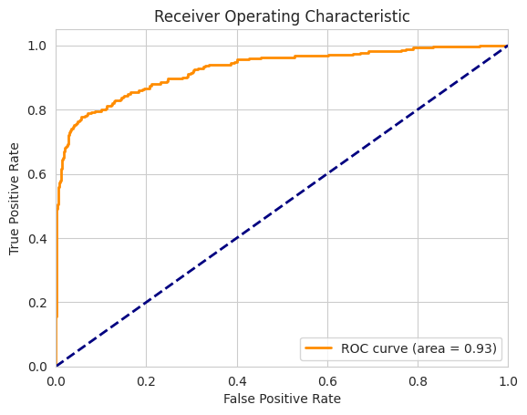

```python
#визуализация ROC-кривой

fpr, tpr, thresholds = roc_curve(y_test, y_pred_proba)
roc_auc = auc(fpr, tpr)

plt.figure()
plt.plot(fpr, tpr, color='darkorange', lw=2, label='ROC curve (area = %0.2f)' % roc_auc)
plt.plot([0, 1], [0, 1], color='navy', lw=2, linestyle='--')
plt.xlim([0.0, 1.0])
plt.ylim([0.0, 1.05])
plt.xlabel('False Positive Rate')
plt.ylabel('True Positive Rate')
plt.title('Receiver Operating Characteristic')
plt.legend(loc="lower right")
plt.show()
```

Значения AUC около 0.93 указывает на способность модели превосходить случайное угадывание . ROC-кривая модели находится выше диагональной линии, это означает, что модель имеет лучшую производительность, чем случайное угадывание.

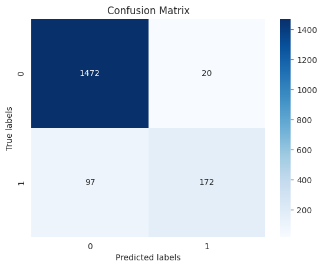

```python
#матрица ошибок

cm = confusion_matrix(y_test, y_pred)
sns.heatmap(cm, annot=True, fmt="d", cmap="Blues")
plt.xlabel('Predicted labels')
plt.ylabel('True labels')
plt.title('Confusion Matrix')
plt.show()
```

```python
cm_df = pd.DataFrame(cm, index=["Actual Negative", "Actual Positive"],
                     columns=["Predicted Negative", "Predicted Positive"])
print("\nМатрица ошибок в формате DataFrame:")
print(cm_df)
```

```
Матрица ошибок в формате DataFrame:
                 Predicted Negative  Predicted Positive
Actual Negative                1472                  20
Actual Positive                  97                 172
```

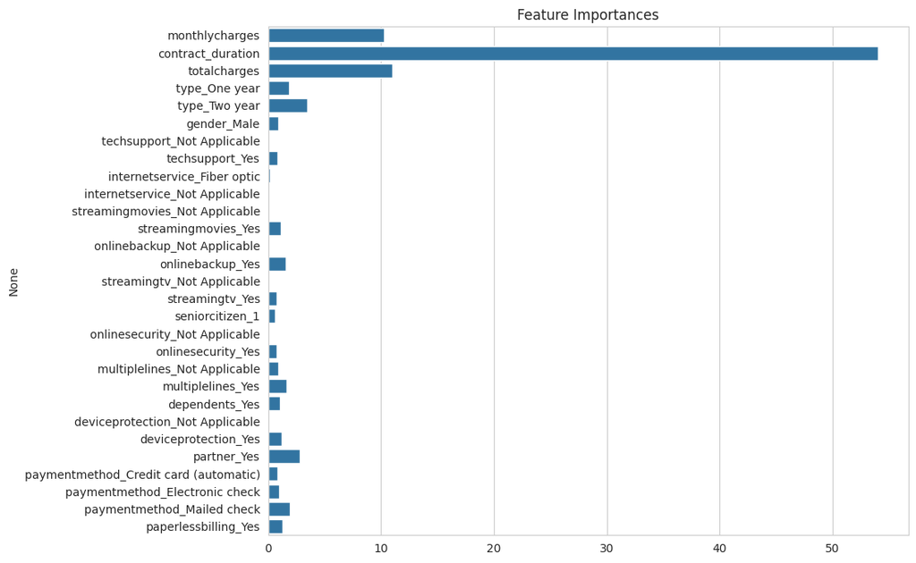

```python
#Анализ важности признаков

feature_importances = best_model.get_feature_importance()
plt.figure(figsize=(10, 8))
sns.barplot(y=X_train_transformed_df.columns, x=feature_importances)
plt.title('Feature Importances')
plt.show()
```

Наиболее важными признаками являются - длительность контракта , следом идут общие и помесячные траты. Эти Признаки являются ключевыми для принятия решений моделью.

## Сохранение модели

```python
#saving model
# naming model file
filename = 'finalized_model.sav'

with open(filename, 'wb') as file:
    # saving model to file
    pickle.dump(best_model, file)
```

# **Шаг 8. Заключение и рекомендации для заказчика**

Основной целью этого проекта была разработка прогнозной модели для «ТелеДом», телекоммуникационного оператора, стремящегося сократить отток клиентов, предлагая акции и специальные условия тем, кто планирует прекратить свои услуги. Цель и задачи проекта выполнены.

Проект начался с загрузки предоставленных наборов данных и проведения первоначальной проверки для понимания структуры, качества и типов доступной информации. Для каждого кадра данных был проведен углубленный исследовательский анализ с последующей необходимой предварительной обработкой данных. Этот этап включал выявление и обработку пропущенных значений, выбросов (менее 3 %) и обеспечение того, чтобы общее качество данных было подходящим для моделирования. Анализ позволил получить представление о доступных функциях и их потенциальной полезности для прогнозирования оттока клиентов.

Выбранные функции были объединены в единый фрейм данных с использованием ключа для унификации данных, что позволило более упростить процесс анализа и моделирования.

Был выполнен дальнейший исследовательский анализ объединенного кадра данных, визуализация распределения признаков и выполнение корреляционного анализа для понимания взаимосвязей между переменными. Все корреляции с оттоком не были сильными. Наиболее значимыми результатами являются продолжительность контракта (0,375). Такая положительная корреляция предполагает, что более длительный срок контракта связан с более высоким уровнем оттока клиентов. Это может указывать на проблемы с обязательствами клиентов или неудовлетворенность ими с течением времени.

Общие расходы (0,303): демонстрирует умеренную положительную корреляцию с оттоком. Более высокие общие расходы могут привести к более высокому оттоку, возможно, из-за воспринимаемой ценности или финансовых ограничений с точки зрения клиента. Партнер (0,227) и «Ежемесячные сборы» (0,226): оба демонстрируют одинаковый уровень положительной корреляции с оттоком. Наличие партнера и более высокие ежемесячные платежи умеренно способствуют оттоку клиентов. Это может отразиться на финансовом бремени и динамике принятия решений в домохозяйствах.

Данные были подготовлены для обучения модели, которое включало разделение на обучающий и тестовый наборы, масштабирование числовых характеристик и кодирование категориальных переменных. Эта подготовка была адаптирована с учетом требований прогнозных моделей и конкретных характеристик данных.

Было обучено несколько моделей (CatBoost и логистическа регрессия, причем обе модели подверглись настройке гиперпараметров для оптимизации их производительности. Этот процесс включал оценку различных алгоритмов и их конфигураций, чтобы найти наиболее эффективное решение для прогнозирования оттока клиентов.

После обучения была выбрана наиболее эффективная модель на основе ее показателей производительности, включая (ROC AUC). Затем выбранная модель была протестирована на отдельном наборе тестовых данных, чтобы подтвердить ее прогностическую способность и обобщаемость.

**Рекомендации Заказчику**

По результатам проекта «ТелеДом» рекомендуется внедрить прогнозную модель для превентивного выявления клиентов из группы риска. Поступая таким образом, компания может ориентировать этих людей на специальные предложения, рекламные акции или персонализированные коммуникационные стратегии, направленные на сохранение их бизнеса. Учитывая результаты корреляции, вот краткие рекомендации для «ТелеДома» по снижению оттока клиентов:

# Загрузка модели и предсказание для случайного пользователя

## Подготовка данных для предсказания

В этом разделе будут произведены следующие шаги

- Создание исходных таблиц и заполнение случайными данными одного абонента
- Предобработка для всех датасетов, такие же как на исходных данных
- Соединение датафреймов в общий датафрейм
- Выполнения предобработки и трансформации точно также как и на исходном общем датафрейме
- Загрузка модели
- Предсказание для этих данных

```python
#creating new datasets from the data
contract_test = pd.read_csv('/content/drive/MyDrive/datasets/contract_new.csv')
internet_test = pd.read_csv('/content/drive/MyDrive/datasets/internet_new.csv')
phone_test=pd.read_csv('/content/drive/MyDrive/datasets/phone_new.csv')
personal_test=pd.read_csv('/content/drive/MyDrive/datasets/personal_new.csv')
```

```python
# # Seed for reproducibility
# np.random.seed(42)  # Setting the random seed
rng = np.random.default_rng(RANDOM_STATE)
```

```python
#Finding the intersection of unique customerIDs across all dataframes to ensure the selected customerID is present in each dataframe
common_ids = set(contract_test['customerID'].unique()) & set(internet_test['customerID'].unique()) & \
             set(phone_test['customerID'].unique()) & set(personal_test['customerID'].unique())
```

```python
# Selecting a random customerID from the intersection
# random_id = np.random.choice(list(common_ids))
random_id = rng.choice(list(common_ids))
```

```python
# Filtering each dataframe for the selected customerID
contract_test = contract_test[contract_test['customerID'] == random_id]
internet_test = internet_test[internet_test['customerID'] == random_id]
phone_test = phone_test[phone_test['customerID'] == random_id]
personal_test = personal_test[personal_test['customerID'] == random_id]
```

```python
contract_test.head()
```

|  | customerID | BeginDate | EndDate | Type | PaperlessBilling | PaymentMethod | MonthlyCharges | TotalCharges |
| --- | --- | --- | --- | --- | --- | --- | --- | --- |
| 4973 | 7852-LECYP | 2019-01-01 | No | Month-to-month | No | Credit card (automatic) | 93.8 | 1255.98 |

```python
internet_test.head()
```

|  | customerID | InternetService | OnlineSecurity | OnlineBackup | DeviceProtection | TechSupport | StreamingTV | StreamingMovies |
| --- | --- | --- | --- | --- | --- | --- | --- | --- |
| 3882 | 7852-LECYP | Fiber optic | Yes | Yes | No | No | No | Yes |

```python
phone_test.head()
```

|  | customerID | MultipleLines |
| --- | --- | --- |
| 4518 | 7852-LECYP | Yes |

```python
personal_test.head()
```

|  | customerID | gender | SeniorCitizen | Partner | Dependents |
| --- | --- | --- | --- | --- | --- |
| 4973 | 7852-LECYP | Male | 1 | Yes | No |

```python
#function for preprosessing contract datatset

def preprocess_data(df):
    """
    Preprocess the data with the following steps:
    - Convert column names to lowercase
    - Remove duplicates
    - Convert 'begindate' and 'enddate' to datetime
    - Convert 'totalcharges' to numeric, replace non-numeric with NaN, then missing values with 0
    - Create a 'churn' column based on 'enddate'
    - Replace missing 'enddate' with a specific date

    Args:
    df (pd.DataFrame): Input dataframe with contract information

    Returns:
    pd.DataFrame: Preprocessed dataframe
    """
    # Convert column names to lowercase
    df.columns = df.columns.str.lower()

    # Remove duplicates
    df.drop_duplicates(inplace=True)

    # Convert 'begindate' and 'enddate' to datetime
    df['begindate'] = pd.to_datetime(df['begindate'])
    df['enddate'] = pd.to_datetime(df['enddate'], errors='coerce')

    # Convert 'totalcharges' to numeric, replace non-numeric with NaN, then fill NaN with 0
    df['totalcharges'] = pd.to_numeric(df['totalcharges'], errors='coerce').fillna(0)

    # Create a 'churn' column based on 'enddate'
    df['churn'] = df['enddate'].notna().astype(int)

    # Replace missing 'enddate' for non-churned customers with a specific date
    replacement_date = pd.Timestamp('2020-02-01')
    df['enddate'] = df['enddate'].fillna(replacement_date)

    return df
```

```python
#preprosessing contract datatset
contract_test = preprocess_data(contract_test)
contract_test.head()
```

|  | customerid | begindate | enddate | type | paperlessbilling | paymentmethod | monthlycharges | totalcharges | churn |
| --- | --- | --- | --- | --- | --- | --- | --- | --- | --- |
| 4973 | 7852-LECYP | 2019-01-01 | 2020-02-01 | Month-to-month | No | Credit card (automatic) | 93.8 | 1255.98 | 0 |

```python
def preprocess_others(df):
    """
    Preprocess the data by converting column names to lowercase.

    Args:
    df (pd.DataFrame): Input dataframe to preprocess.

    Returns:
    pd.DataFrame: Preprocessed dataframe with lowercase column names.
    """
    df.columns = df.columns.str.lower()
    return df
```

```python
#preprosessing other datasets
internet_test = preprocess_others(internet_test)
personal_test = preprocess_others(personal_test)
phone_test = preprocess_others(phone_test)
```

```python
internet_test.head()
```

|  | customerid | internetservice | onlinesecurity | onlinebackup | deviceprotection | techsupport | streamingtv | streamingmovies |
| --- | --- | --- | --- | --- | --- | --- | --- | --- |
| 3882 | 7852-LECYP | Fiber optic | Yes | Yes | No | No | No | Yes |

```python
personal_test.head()
```

|  | customerid | gender | seniorcitizen | partner | dependents |
| --- | --- | --- | --- | --- | --- |
| 4973 | 7852-LECYP | Male | 1 | Yes | No |

```python
phone_test.head()
```

|  | customerid | multiplelines |
| --- | --- | --- |
| 4518 | 7852-LECYP | Yes |

```python
def merge_dataframes(contract, personal, internet, phone):
    """
    Merge dataframes on 'customerid' with an outer join to include all records.

    Args:
    contract (pd.DataFrame): Contract information dataframe.
    personal (pd.DataFrame): Personal information dataframe.
    internet (pd.DataFrame): Internet service information dataframe.
    phone (pd.DataFrame): Phone service information dataframe.

    Returns:
    pd.DataFrame: Merged dataframe containing all information.
    """
    # Merge contract with personal
    merged_df = contract.merge(personal, on='customerid', how='outer')

    # Add data from internet
    merged_df = merged_df.merge(internet, on='customerid', how='outer')

    # Add data from phone
    final_df = merged_df.merge(phone, on='customerid', how='outer')

    return final_df
```

```python
def preprocess_merged_data(df):
    """
    Preprocess the merged dataframe by filling missing values, converting data types,
    removing duplicates, and calculating new columns.

    Args:
    df (pd.DataFrame): Merged dataframe to preprocess.

    Returns:
    pd.DataFrame: Preprocessed dataframe ready for analysis or modeling.
    """
    # Calculate the duration of the contract and add a new column
    df['contract_duration'] = (df['enddate'] - df['begindate']).dt.days

    # Select columns of type object or float for further processing
    cols = df.select_dtypes(include=['object', 'float']).columns.tolist()

    # Manually identified columns to include
    additional_cols = ['churn', 'contract_duration', 'seniorcitizen']

    # Combine lists while ensuring uniqueness
    cols = list(set(cols + additional_cols))

    # Create a copy of the dataframe with selected columns
    df = df[cols].copy()

    # Remove duplicates
    df.drop_duplicates(keep=False, inplace=True)

    # Filling missing values for 'multiplelines'
    df['multiplelines'].fillna('Not Applicable', inplace=True)

    # Assume missing values indicate no internet service for specific columns
    internet_service_columns = [
        'internetservice', 'onlinesecurity', 'onlinebackup', 'deviceprotection',
        'techsupport', 'streamingtv', 'streamingmovies'
    ]

    # Fill missing values with 'Not Applicable' for internet service columns
    df[internet_service_columns] = df[internet_service_columns].fillna('Not Applicable')

    # Convert 'seniorcitizen' to string for consistency
    df['seniorcitizen'] = df['seniorcitizen'].astype(str)

    # Set 'customerid' as the index of the dataframe
    df.set_index('customerid', inplace=True)

    return df
```

```python
merged_df = merge_dataframes(contract_test, personal_test, internet_test, phone_test)
preprocessed_df = preprocess_merged_data(merged_df)
```

```python
merged_df.info()
```

```
<class 'pandas.core.frame.DataFrame'>
Int64Index: 1 entries, 0 to 0
Data columns (total 22 columns):
 #   Column             Non-Null Count  Dtype
---  ------             --------------  -----
 0   customerid         1 non-null      object
 1   begindate          1 non-null      datetime64[ns]
 2   enddate            1 non-null      datetime64[ns]
 3   type               1 non-null      object
 4   paperlessbilling   1 non-null      object
 5   paymentmethod      1 non-null      object
 6   monthlycharges     1 non-null      float64
 7   totalcharges       1 non-null      float64
 8   churn              1 non-null      int64
 9   gender             1 non-null      object
 10  seniorcitizen      1 non-null      int64
 11  partner            1 non-null      object
 12  dependents         1 non-null      object
 13  internetservice    1 non-null      object
 14  onlinesecurity     1 non-null      object
 15  onlinebackup       1 non-null      object
 16  deviceprotection   1 non-null      object
 17  techsupport        1 non-null      object
 18  streamingtv        1 non-null      object
 19  streamingmovies    1 non-null      object
 20  multiplelines      1 non-null      object
 21  contract_duration  1 non-null      int64
dtypes: datetime64[ns](2), float64(2), int64(3), object(15)
memory usage: 184.0+ bytes
```

```python
preprocessed_df.head()
```

| customerid | type | monthlycharges | gender | techsupport | internetservice | streamingmovies | onlinebackup | churn | streamingtv | seniorcitizen | contract_duration | onlinesecurity | multiplelines | dependents | deviceprotection | partner | totalcharges | paymentmethod | paperlessbilling |
| --- | --- | --- | --- | --- | --- | --- | --- | --- | --- | --- | --- | --- | --- | --- | --- | --- | --- | --- | --- |
| 7852-LECYP | Month-to-month | 93.8 | Male | No | Fiber optic | Yes | Yes | 0 | No | 1 | 396 | Yes | Yes | No | No | Yes | 1255.98 | Credit card (automatic) | No |

```python
print(preprocessed_df.info())
```

```
<class 'pandas.core.frame.DataFrame'>
Index: 1 entries, 7852-LECYP to 7852-LECYP
Data columns (total 19 columns):
 #   Column             Non-Null Count  Dtype
---  ------             --------------  -----
 0   type               1 non-null      object
 1   monthlycharges     1 non-null      float64
 2   gender             1 non-null      object
 3   techsupport        1 non-null      object
 4   internetservice    1 non-null      object
 5   streamingmovies    1 non-null      object
 6   onlinebackup       1 non-null      object
 7   churn              1 non-null      int64
 8   streamingtv        1 non-null      object
 9   seniorcitizen      1 non-null      object
 10  contract_duration  1 non-null      int64
 11  onlinesecurity     1 non-null      object
 12  multiplelines      1 non-null      object
 13  dependents         1 non-null      object
 14  deviceprotection   1 non-null      object
 15  partner            1 non-null      object
 16  totalcharges       1 non-null      float64
 17  paymentmethod      1 non-null      object
 18  paperlessbilling   1 non-null      object
dtypes: float64(2), int64(2), object(15)
memory usage: 160.0+ bytes
None
```

```python
preprocessed_df.info()
```

```
<class 'pandas.core.frame.DataFrame'>
Index: 1 entries, 7852-LECYP to 7852-LECYP
Data columns (total 19 columns):
 #   Column             Non-Null Count  Dtype
---  ------             --------------  -----
 0   type               1 non-null      object
 1   monthlycharges     1 non-null      float64
 2   gender             1 non-null      object
 3   techsupport        1 non-null      object
 4   internetservice    1 non-null      object
 5   streamingmovies    1 non-null      object
 6   onlinebackup       1 non-null      object
 7   churn              1 non-null      int64
 8   streamingtv        1 non-null      object
 9   seniorcitizen      1 non-null      object
 10  contract_duration  1 non-null      int64
 11  onlinesecurity     1 non-null      object
 12  multiplelines      1 non-null      object
 13  dependents         1 non-null      object
 14  deviceprotection   1 non-null      object
 15  partner            1 non-null      object
 16  totalcharges       1 non-null      float64
 17  paymentmethod      1 non-null      object
 18  paperlessbilling   1 non-null      object
dtypes: float64(2), int64(2), object(15)
memory usage: 160.0+ bytes
```

```python
# Assuming preprocessed_df DataFrame and 'churn' is the target variable
X = preprocessed_df.drop(['churn'], axis=1)  # Drop target variable
y = preprocessed_df['churn']
```

```python
# preprosessing
X_new_transformed = preprocessor.transform(X)


new_features = new_numeric_features + new_categorical_features.tolist()


X_new_transformed_df = pd.DataFrame(X_new_transformed, columns=new_features)
```

```python
X_new_transformed_df.index = preprocessed_df.index
```

```python
X_new_transformed_df.head()
```

| customerid | monthlycharges | contract_duration | totalcharges | type_One year | type_Two year | gender_Male | techsupport_Not Applicable | techsupport_Yes | internetservice_Fiber optic | internetservice_Not Applicable | ... | multiplelines_Not Applicable | multiplelines_Yes | dependents_Yes | deviceprotection_Not Applicable | deviceprotection_Yes | partner_Yes | paymentmethod_Credit card (automatic) | paymentmethod_Electronic check | paymentmethod_Mailed check | paperlessbilling_Yes |
| --- | --- | --- | --- | --- | --- | --- | --- | --- | --- | --- | --- | --- | --- | --- | --- | --- | --- | --- | --- | --- | --- |
| 7852-LECYP | 0.965575 | -0.729465 | -0.404384 | 0.0 | 0.0 | 1.0 | 0.0 | 0.0 | 1.0 | 0.0 | ... | 0.0 | 1.0 | 0.0 | 0.0 | 0.0 | 1.0 | 1.0 | 0.0 | 0.0 | 0.0 |

1 rows × 29 columns

```python
X_new_transformed_df.info()
```

```
<class 'pandas.core.frame.DataFrame'>
Index: 1 entries, 7852-LECYP to 7852-LECYP
Data columns (total 29 columns):
 #   Column                                 Non-Null Count  Dtype
---  ------                                 --------------  -----
 0   monthlycharges                         1 non-null      float64
 1   contract_duration                      1 non-null      float64
 2   totalcharges                           1 non-null      float64
 3   type_One year                          1 non-null      float64
 4   type_Two year                          1 non-null      float64
 5   gender_Male                            1 non-null      float64
 6   techsupport_Not Applicable             1 non-null      float64
 7   techsupport_Yes                        1 non-null      float64
 8   internetservice_Fiber optic            1 non-null      float64
 9   internetservice_Not Applicable         1 non-null      float64
```

[output cut: 21 more lines]

```python
# loading model from file
with open(filename, 'rb') as file:
    loaded_model = pickle.load(file)
```

```python
y_pred = loaded_model.predict(X_new_transformed)
```

```python
# Printing model predictions for the new data
print("Model predictions for new data:")
print(y_pred)
```

```
Model predictions for new data:
[0]
```

```python
# finging real value for this user
real_value = df.loc[random_id, 'churn']

# print real value
print(f"Real value in original df {random_id}: {real_value}")
```

```
Real value in original df 7852-LECYP: 0
```

Загрузка модели и предсказание для случайного абонента успешно выполнены.